# PIntenWi_analysis

# 1 Study 1

## 1.1 Peparations

### 1.1.1 load packages and functions

```r
library(tidyverse)
library(ggplot2)
library(lme4)
library(kableExtra)
library(papaja)
```

```r
source("./functions/glmm_stability.r") # model stability
source("./functions/diagnostic_fcns.r") # diagnostic functions
source("./functions/boot_glmm.r") # bootstrapping
```

### 1.1.2 prepare data

```r
#load data
data_fam <- read.csv2("./data/study1/data_fam.csv", stringsAsFactors=TRUE)
data_fam_long <- read.csv2("./data/study1/data_fam_long.csv", stringsAsFactors=TRUE)
data_long <- read.csv2("./data/study1/data_long.csv", stringsAsFactors=TRUE)
data_wide_s1 <- read.csv2("./data/study1/data_wide_s1.csv", stringsAsFactors=TRUE)

data_long$trial.f <- as.factor(data_long$trial)
data_long$condition <- relevel(data_long$condition, ref = "dual_identity")

data_long <- data_long %>%
  mutate(condition_ref_control = relevel(data_long$condition, ref = "control"),
         condition_ref_CoL = relevel(data_long$condition, ref = "change_of_location"))
```

## 1.2 Descriptives

```r
# Function to convert floating-point years to "years;months"
convert_to_years_months <- function(age) {
  years <- floor(age)
  months <- floor((age - years) * 12)
  paste0(years, ";", months)
}
```

```r
# N
length(unique(data_long$id))
```

```
## [1] 127
```

```r
mean_age_s1 <- mean(data_wide_s1$age_years)
mean_age_s1
```

```
## [1] 5.958574
```

```r
sd_age_s1 <- sd(data_wide_s1$age_years)
sd_age_s1
```

```
## [1] 1.15067
```

```r
#z-transformation
data_long$z_age_years <- as.numeric(scale(data_long$age_years, center = mean_age_s1, scale = sd_age_s1))

min_age_s1 <- min(data_wide_s1$age_years)
min_age_s1
```

```
## [1] 4.030137
```

```r
max_age_s1 <- max(data_wide_s1$age_years)
max_age_s1
```

```
## [1] 7.956164
```

### 1.2.1 Probability of correct choices as a function of condition and age

```r
correct.choice <- data_long %>%
  filter(!(is.na(t_correct))) %>%
  group_by(condition, age_years_full) %>%
  count(t_correct) %>%
  mutate(prop = n/sum(n))%>%
  filter(t_correct == "1")

correct.choice
```

```
## # A tibble: 12 × 5
## # Groups:   condition, age_years_full [12]
##    condition          age_years_full t_correct     n  prop
##    <fct>                       <int>     <int> <int> <dbl>
##  1 dual_identity                   4         1    29 0.558
##  2 dual_identity                   5         1    39 0.765
##  3 dual_identity                   6         1    48 0.857
##  4 dual_identity                   7         1    54 0.931
##  5 change_of_location              4         1    17 0.293
##  6 change_of_location              5         1    29 0.460
##  7 change_of_location              6         1    46 0.719
##  8 change_of_location              7         1    52 0.867
##  9 control                         4         1    40 0.769
## 10 control                         5         1    48 0.857
## 11 control                         6         1    49 0.817
## 12 control                         7         1    51 0.85
```

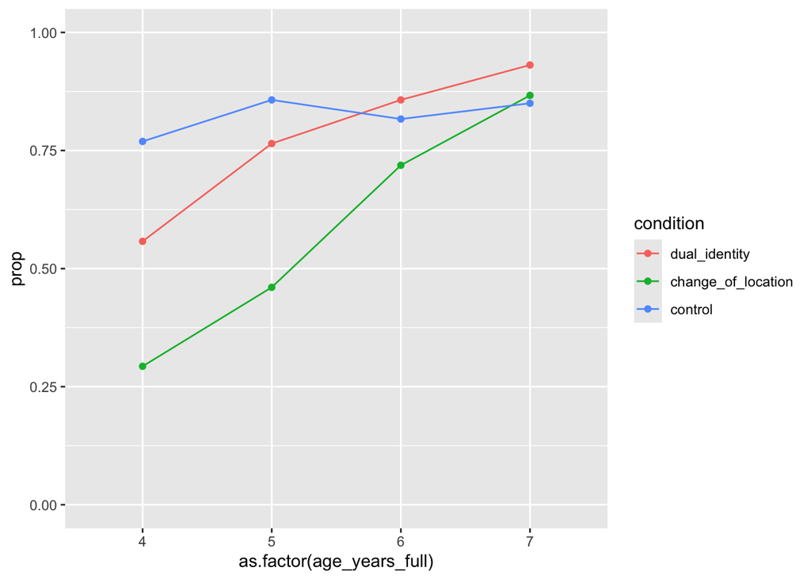

```r
ggplot(data = correct.choice, aes(x = as.factor(age_years_full), y = prop, group = condition, color = condition)) +
  geom_point(aes(group = condition)) +
  geom_line(aes(group = condition)) +
  ylim(0,1)
```

```r
table(data_wide_s1$age_years_full)
```

```
##
##  4  5  6  7
## 32 33 32 30
```

```r
# as a table
correct.choice.s1 <- data_long %>%
  filter(!is.na(t_correct)) %>%
  group_by(condition_ref_control, age_years_full) %>%
  summarise(prop = mean(t_correct == "1"), .groups = "drop") %>%
  mutate(prop = round(prop * 100)) %>%  # convert to percentage
  pivot_wider(names_from = condition_ref_control, values_from = prop, values_fill = 0)

correct.choice.s1$age_years_full[1] <- paste0(correct.choice.s1$age_years_full[1], " ($n$ = ", table(data_wide_s1$age_years_full)[1], ")")
correct.choice.s1$age_years_full[2] <- paste0(correct.choice.s1$age_years_full[2], " ($n$ = ", table(data_wide_s1$age_years_full)[2], ")")
correct.choice.s1$age_years_full[3] <- paste0(correct.choice.s1$age_years_full[3], " ($n$ = ", table(data_wide_s1$age_years_full)[3], ")")
correct.choice.s1$age_years_full[4] <- paste0(correct.choice.s1$age_years_full[4], " ($n$ = ", table(data_wide_s1$age_years_full)[4], ")")

kable(correct.choice.s1, "html",
      booktabs = T,
      escape = F,
      align = c(rep("c")),
      caption = "Probability of correct intentionality judgments per age groups and condition",
      col.names = c("Age in years","Control","Dual identity", "Change of location")) %>%
  add_header_above(c(" " = 1, "Condition" = 3), bold = T, italic = T) %>%
  kable_styling(full_width = T)
```

Table 1.1: Probability of correct intentionality judgments per age groups and condition

| Age in years | Condition Control | Condition Dual identity | Condition Change of location |
| --- | --- | --- | --- |
| 4 ($n$ = 32) | 77 | 56 | 29 |
| 5 ($n$ = 33) | 86 | 76 | 46 |
| 6 ($n$ = 32) | 82 | 86 | 72 |
| 7 ($n$ = 30) | 85 | 93 | 87 |

### 1.2.2 consistency

```r
consis <- data_long %>%
  filter(!is.na(t_correct)) %>%
  group_by(consis) %>%
  summarise(prop = mean(t_correct == "1")) %>%
  mutate(across(where(is.numeric), ~round(., 3)))
consis
```

```
## # A tibble: 2 × 2
##   consis  prop
##   <fct>  <dbl>
## 1 C      0.688
## 2 I      0.767
```

```r
# as a table
correct.choice.s1.c <- data_long %>%
  filter(!is.na(t_correct)) %>%
  group_by(condition_ref_CoL, consis, age_years_full) %>%
  summarise(prop = mean(t_correct == "1")) %>%
  mutate(across(where(is.numeric), ~round(., 2))) %>%
  pivot_wider(names_from = c("condition_ref_CoL","consis"), values_from = prop, values_fill = 0)
correct.choice.s1.c$age_years_full[1] <- paste0(correct.choice.s1.c$age_years_full[1], " (n = ", table(data_wide_s1$age_years_full)[1], ")")
correct.choice.s1.c$age_years_full[2] <- paste0(correct.choice.s1.c$age_years_full[2], " (n = ", table(data_wide_s1$age_years_full)[2], ")")
correct.choice.s1.c$age_years_full[3] <- paste0(correct.choice.s1.c$age_years_full[3], " (n = ", table(data_wide_s1$age_years_full)[3], ")")
correct.choice.s1.c$age_years_full[4] <- paste0(correct.choice.s1.c$age_years_full[4], " (n = ", table(data_wide_s1$age_years_full)[4], ")")

kable(correct.choice.s1.c, "html",
      booktabs = T,
      escape = F,
      align = c(rep("c")),
      caption = "Probability of correct intentionality judgments per age groups and condition",
      col.names = c("Age in years","Consistent","Inconsistent", "Consistent","Inconsistent","Consistent","Inconsistent")) %>%
  add_header_above(c(" " = 1, "Change of location" = 2, "Dual identity" = 2, "Control" = 2), bold = T) %>%
  kable_styling(full_width = T)
```

Table 1.2: Probability of correct intentionality judgments per age groups and condition

| Age in years | Change of location Consistent | Change of location Inconsistent | Dual identity Consistent | Dual identity Inconsistent | Control Consistent | Control Inconsistent |
| --- | --- | --- | --- | --- | --- | --- |
| 4 (n = 32) | 0.20 | 0.39 | 0.54 | 0.58 | 0.69 | 0.85 |
| 5 (n = 33) | 0.34 | 0.58 | 0.80 | 0.73 | 0.86 | 0.86 |
| 6 (n = 32) | 0.66 | 0.78 | 0.79 | 0.93 | 0.77 | 0.87 |
| 7 (n = 30) | 0.87 | 0.87 | 0.93 | 0.93 | 0.87 | 0.83 |

### 1.2.3 Probability of correct choices in consistent trials as a function of condition and age

```r
correct.choice_C <- data_long %>%
  filter(!(is.na(t_correct))) %>%
  filter(consis == "C") %>%
  group_by(condition, age_years_full) %>%
  count(t_correct) %>%
  mutate(prop = n/sum(n))%>%
  filter(t_correct == "1")

correct.choice_C
```

```
## # A tibble: 12 × 5
## # Groups:   condition, age_years_full [12]
##    condition          age_years_full t_correct     n  prop
##    <fct>                       <int>     <int> <int> <dbl>
##  1 dual_identity                   4         1    14 0.538
##  2 dual_identity                   5         1    20 0.8
##  3 dual_identity                   6         1    22 0.786
##  4 dual_identity                   7         1    27 0.931
##  5 change_of_location              4         1     6 0.2
##  6 change_of_location              5         1    11 0.344
##  7 change_of_location              6         1    21 0.656
##  8 change_of_location              7         1    26 0.867
##  9 control                         4         1    18 0.692
## 10 control                         5         1    24 0.857
## 11 control                         6         1    23 0.767
## 12 control                         7         1    26 0.867
```

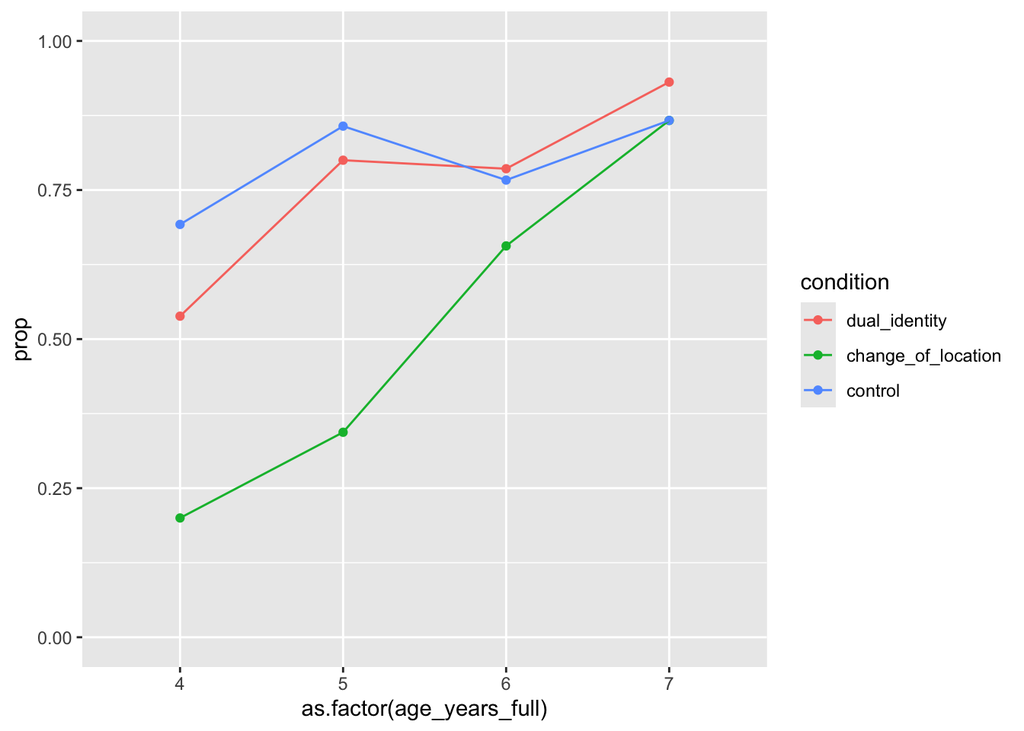

```r
ggplot(data = correct.choice_C, aes(x = as.factor(age_years_full), y = prop, group = condition, color = condition)) +
  geom_point(aes(group = condition)) +
  geom_line(aes(group = condition)) +
  ylim(0,1)
```

### 1.2.4 Probability of correct choices in inconsistent trials as a function of condition and age

```r
correct.choice_I <- data_long %>%
  filter(!(is.na(t_correct))) %>%
  filter(consis == "I") %>%
  group_by(condition, age_years_full) %>%
  count(t_correct) %>%
  mutate(prop = n/sum(n))%>%
  filter(t_correct == "1")

correct.choice_I
```

```
## # A tibble: 12 × 5
## # Groups:   condition, age_years_full [12]
##    condition          age_years_full t_correct     n  prop
##    <fct>                       <int>     <int> <int> <dbl>
##  1 dual_identity                   4         1    15 0.577
##  2 dual_identity                   5         1    19 0.731
##  3 dual_identity                   6         1    26 0.929
##  4 dual_identity                   7         1    27 0.931
##  5 change_of_location              4         1    11 0.393
##  6 change_of_location              5         1    18 0.581
##  7 change_of_location              6         1    25 0.781
##  8 change_of_location              7         1    26 0.867
##  9 control                         4         1    22 0.846
## 10 control                         5         1    24 0.857
## 11 control                         6         1    26 0.867
## 12 control                         7         1    25 0.833
```

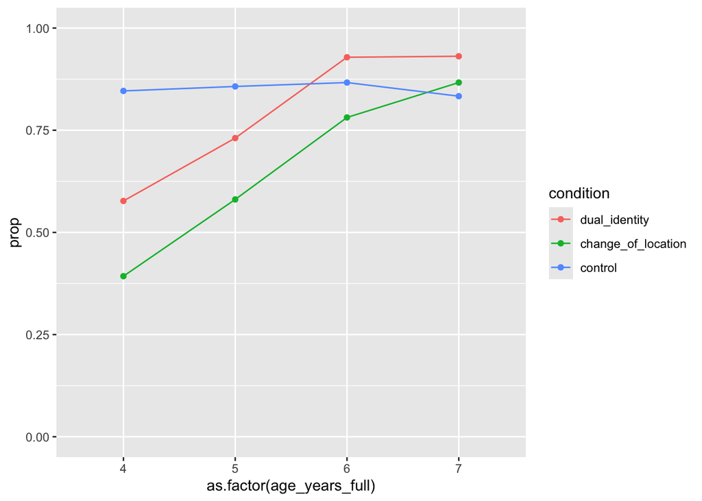

```r
ggplot(data = correct.choice_I, aes(x = as.factor(age_years_full), y = prop, group = condition, color = condition)) +
  geom_point(aes(group = condition)) +
  geom_line(aes(group = condition)) +
  ylim(0,1)
```

### 1.2.5 Plot: raw responses as a function of condition and age groups

```r
# Calculate percentages
raw_responses <- data_long %>%
  filter(!is.na(res_t)) %>%
  group_by(age_years_full, condition_ref_control, consis) %>%
  count(res_t) %>%
  mutate(percentage = n / sum(n) * 100)

# Convert factors
raw_responses$res_t <- factor(raw_responses$res_t, labels = c("self", "wind"))
raw_responses$consis <- factor(raw_responses$consis, labels = c("C", "I"))
```

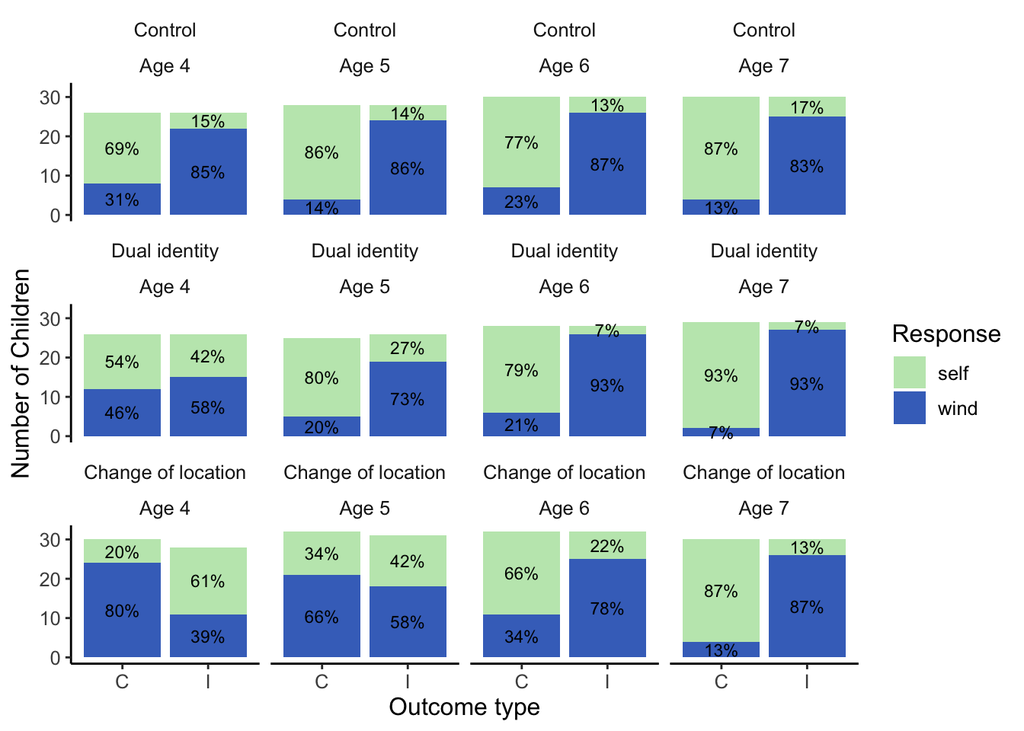

```r
# Plot
ggplot(data = raw_responses, aes(fill = res_t, y = n, x = consis)) +
  geom_bar(stat = "identity") +
  geom_text(aes(label = paste0(round(percentage), "%")),
            position = position_stack(vjust = 0.5), size = 3, color = "black") +  # Add data labels
  labs(fill = "Response") +
  xlab("Outcome type") +
  ylab("Number of Children") +
  scale_fill_manual(values = c("#c1e7bb", "#4472C4")) +
  facet_wrap(~condition_ref_control + age_years_full,
             labeller = labeller(condition_ref_control = c("control" = "Control", "dual_identity" = "Dual identity", "change_of_location" = "Change of location"),
                                 age_years_full = c("4" = "Age 4", "5" = "Age 5", "6" = "Age 6", "7" = "Age 7"))) +
  theme_classic() +
  theme(panel.grid.major = element_blank(),
        panel.background = element_blank(),
        panel.grid.minor = element_blank(),
        axis.line = element_line(colour = "black"),
        text = element_text(size = 12),
        #strip.text.x = element_blank(),  # Remove x-axis facet labels
        strip.background = element_blank())  # Remove background for facet labels
```

## 1.3 Statistical analyses

### 1.3.1 fit null and reduced model

```r
null = glmer(t_correct ~ z_age_years + trial.f + consis + (1+condition + consis|id) + (1|experimenter),
                 family = "binomial",
                 data = data_long,
             control = glmerControl(optimizer = "bobyqa", optCtrl = list(maxfun = 100000)))
```

```
## boundary (singular) fit: see help('isSingular')
```

```r
red = glmer(t_correct ~ condition + z_age_years + trial.f + consis + (1+condition + consis|id) + (1|experimenter),
                 family = "binomial",
                 data = data_long,
            control = glmerControl(optimizer = "bobyqa", optCtrl = list(maxfun = 100000)))
```

```
## boundary (singular) fit: see help('isSingular')
```

### 1.3.2 fit full model

```r
full = glmer(t_correct ~ condition * z_age_years + trial.f + consis + (1+ condition + consis |id) + (1|experimenter),
                 family = "binomial",
                 data = data_long,
             control = glmerControl(optimizer = "bobyqa", optCtrl = list(maxfun = 100000)))
```

```
## boundary (singular) fit: see help('isSingular')
```

### 1.3.3 full-null model comparisons

```r
as.data.frame(anova(null, full, test="Chisq"))
```

```
##      npar      AIC      BIC    logLik deviance   Chisq Df   Pr(>Chisq)
## null   15 727.7648 795.8152 -348.8824 697.7648      NA NA           NA
## full   19 669.6745 755.8716 -315.8372 631.6745 66.0903  4 1.516102e-13
```

### 1.3.4 Test assumptions

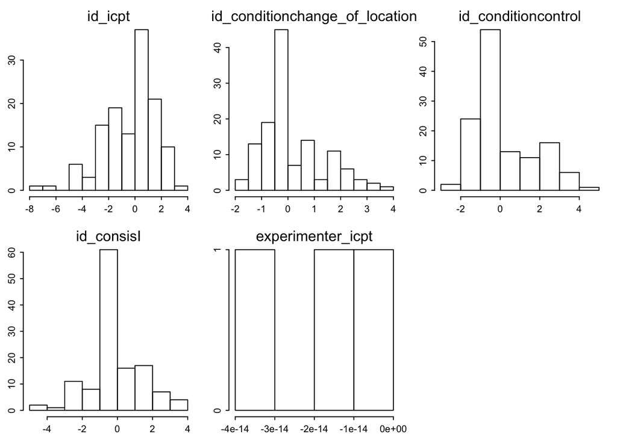

```r
# Normal distribution of random effects
ranef.diagn.plot(full)
```

```r
# Model stability
m.stab = glmm.model.stab(model.res = full, para = T)

saveRDS(m.stab, file = "workspaces/PIntenWi_m_stab.RData")
```

```r
round(m.stab$summary[, -1], 3)
```

```
##                                                   orig    min    max
## (Intercept)                                      2.656  1.827  2.593
## conditionchange_of_location                     -2.719 -2.696 -1.815
## conditioncontrol                                -0.835 -0.995  0.036
## z_age_years                                      2.044  1.440  2.108
## trial.f2                                         0.678  0.293  1.063
## consisI                                          0.863  0.496  1.015
## conditionchange_of_location:z_age_years         -0.152 -0.266  0.548
## conditioncontrol:z_age_years                    -1.793 -1.867 -1.185
## id@(Intercept)@NA                                3.390  1.900  3.312
## id@conditionchange_of_location@NA                2.300  0.539  2.124
## id@conditioncontrol@NA                           3.082  1.008  3.078
## id@consisI@NA                                    2.497  1.601  2.522
## id@(Intercept)@conditionchange_of_location      -0.867 -1.000 -0.424
## id@(Intercept)@conditioncontrol                 -0.839 -0.909 -0.623
## id@(Intercept)@consisI                          -0.252 -0.467 -0.043
## id@conditionchange_of_location@conditioncontrol  0.999  0.651  1.000
## id@conditionchange_of_location@consisI          -0.045 -0.769  0.538
## id@conditioncontrol@consisI                     -0.076 -0.484  0.078
## experimenter@(Intercept)@NA                      0.000  0.000  0.122
```

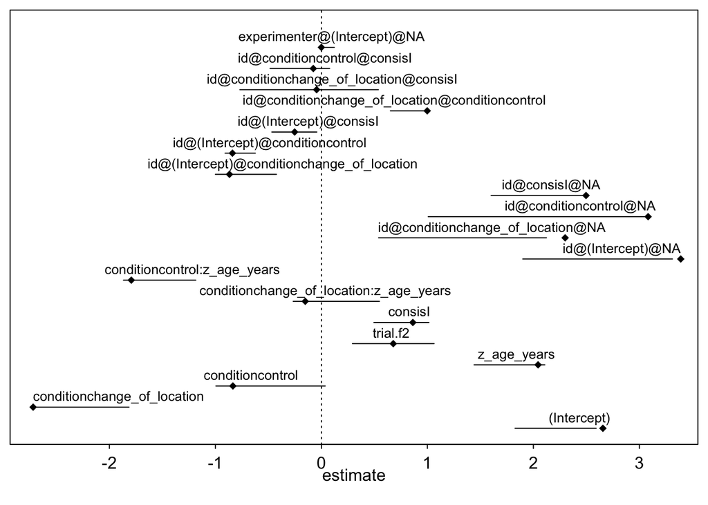

```r
m.stab.plot(m.stab$summary[, -1])
```

```r
# Collinearity
full.coll <- glmer(t_correct ~ condition + z_age_years + trial.f + consis + (1+condition + consis|id) + (1|experimenter),
                   data = data_long,
                   family = binomial,
                   control = glmerControl(optimizer = "bobyqa", optCtrl = list(maxfun = 100000))) # model without interaction
```

```
## boundary (singular) fit: see help('isSingular')
```

```r
car::vif(full.coll)
```

```
##                 GVIF Df GVIF^(1/(2*Df))
## condition   1.710808  2        1.143669
## z_age_years 1.711418  1        1.308212
## trial.f     1.301912  1        1.141014
## consis      1.063952  1        1.031481
```

```r
# Overdispersion
overdisp.test(full)
```

```
##      chisq  df P dispersion.parameter
## 1 218.7879 671 1            0.3260625
```

### 1.3.5 model results

```r
summary(full)
```

```
## Generalized linear mixed model fit by maximum likelihood (Laplace
##   Approximation) [glmerMod]
##  Family: binomial  ( logit )
## Formula: t_correct ~ condition * z_age_years + trial.f + consis + (1 +
##     condition + consis | id) + (1 | experimenter)
##    Data: data_long
## Control: glmerControl(optimizer = "bobyqa", optCtrl = list(maxfun = 1e+05))
##
##      AIC      BIC   logLik deviance df.resid
##    669.7    755.9   -315.8    631.7      671
##
## Scaled residuals:
##     Min      1Q  Median      3Q     Max
## -2.2775 -0.2010  0.1577  0.3146  1.7833
##
## Random effects:
##  Groups       Name                        Variance  Std.Dev.  Corr
##  id           (Intercept)                 1.149e+01 3.390e+00
##               conditionchange_of_location 5.288e+00 2.300e+00 -0.87
##               conditioncontrol            9.502e+00 3.082e+00 -0.84  1.00
##               consisI                     6.233e+00 2.497e+00 -0.25 -0.04 -0.08
##  experimenter (Intercept)                 5.717e-15 7.561e-08
## Number of obs: 690, groups:  id, 127; experimenter, 3
##
## Fixed effects:
##                                         Estimate Std. Error z value Pr(>|z|)
## (Intercept)                               2.6293     0.8221   3.198 0.001382
## conditionchange_of_location              -2.7173     0.8224  -3.304 0.000952
## conditioncontrol                         -0.8115     0.8251  -0.984 0.325330
## z_age_years                               2.0477     0.6256   3.273 0.001064
## trial.f2                                  0.6781     0.2981   2.275 0.022911
## consisI                                   0.8632     0.4409   1.958 0.050263
## conditionchange_of_location:z_age_years  -0.1523     0.5743  -0.265 0.790811
## conditioncontrol:z_age_years             -1.7962     0.6441  -2.789 0.005293
##
## (Intercept)                             **
## conditionchange_of_location             ***
## conditioncontrol
## z_age_years                             **
## trial.f2                                *
## consisI                                 .
## conditionchange_of_location:z_age_years
## conditioncontrol:z_age_years            **
## ---
## Signif. codes:  0 '***' 0.001 '**' 0.01 '*' 0.05 '.' 0.1 ' ' 1
##
## Correlation of Fixed Effects:
##             (Intr) cndt__ cndtnc z_g_yr trl.f2 conssI c__:__
## cndtnchng__ -0.924
## condtncntrl -0.821  0.819
## z_age_years  0.589 -0.616 -0.484
## trial.f2     0.054 -0.209 -0.001  0.193
## consisI      0.006 -0.199 -0.106  0.181  0.102
## cndtnc__:__ -0.463  0.484  0.483 -0.797 -0.015 -0.004
## cndtncnt:__ -0.553  0.578  0.491 -0.910 -0.145 -0.148  0.785
## optimizer (bobyqa) convergence code: 0 (OK)
## boundary (singular) fit: see help('isSingular')
```

```r
# Confidence intervals
boot.res = boot.glmm.pred(model.res = full, excl.warnings = T, nboots = 1000, para = T)

saveRDS(boot.res, file = "workspaces/PIntenWi_boot_m1.RData")
```

```r
# save model results in data frame
table.model.1 <- tibble(coefs = c("(Intercept)", "CoL","control",
                             "z_age_years", "trial.f2","consisI",
                             "CoL:z_age_years", "control:z_age_years"),
                      estimate = c(summary(full)$coefficients[,1]),
                      SE = c(summary(full)$coefficients[,2]),
                      z = c(summary(full)$coefficients[,3]),
                      boot_lower = boot.res[["ci.estimates"]][["X2.5."]],
                      boot_upper = boot.res[["ci.estimates"]][["X97.5."]],
                      OR = exp(estimate),
                      p = c(summary(full)$coefficients[,4]))

table.model.1[,2:8] <- round(table.model.1[,2:8],3)

table.model.1$p <- printp(table.model.1$p)

table.model.1
```

```
## # A tibble: 8 × 8
##   coefs               estimate    SE      z boot_lower boot_upper     OR p
##   <chr>                  <dbl> <dbl>  <dbl>      <dbl>      <dbl>  <dbl> <chr>
## 1 (Intercept)            2.63  0.822  3.20       1.68       18.6  13.9   .001
## 2 CoL                   -2.72  0.822 -3.30     -18.3        -1.8   0.066 .001
## 3 control               -0.811 0.825 -0.984     -7.92        3.38  0.444 .325
## 4 z_age_years            2.05  0.626  3.27       1.25       15.1   7.75  .001
## 5 trial.f2               0.678 0.298  2.28       0.113       5.98  1.97  .023
## 6 consisI                0.863 0.441  1.96       0.129      12.8   2.37  .050
## 7 CoL:z_age_years       -0.152 0.574 -0.265     -2.8        11.6   0.859 .791
## 8 control:z_age_years   -1.80  0.644 -2.79     -14.6        -0.72  0.166 .005
```

#### 1.3.5.1 Model results for other reference groups (using recoded variables)

```r
full_ref_control = glmer(t_correct ~ condition_ref_control * z_age_years + trial.f + consis + (1+condition + consis|id) + (1|experimenter),
                 family = "binomial",
                 data = data_long,
             control = glmerControl(optimizer = "bobyqa", optCtrl = list(maxfun = 100000)))
```

```
## boundary (singular) fit: see help('isSingular')
```

```r
summary(full_ref_control)
```

```
## Generalized linear mixed model fit by maximum likelihood (Laplace
##   Approximation) [glmerMod]
##  Family: binomial  ( logit )
## Formula: t_correct ~ condition_ref_control * z_age_years + trial.f + consis +
##     (1 + condition + consis | id) + (1 | experimenter)
##    Data: data_long
## Control: glmerControl(optimizer = "bobyqa", optCtrl = list(maxfun = 1e+05))
##
##      AIC      BIC   logLik deviance df.resid
##    669.7    755.9   -315.8    631.7      671
##
## Scaled residuals:
##     Min      1Q  Median      3Q     Max
## -2.2775 -0.2010  0.1577  0.3146  1.7833
##
## Random effects:
##  Groups       Name                        Variance Std.Dev. Corr
##  id           (Intercept)                 11.494   3.390
##               conditionchange_of_location  5.288   2.300    -0.87
##               conditioncontrol             9.502   3.082    -0.84  1.00
##               consisI                      6.233   2.497    -0.25 -0.04 -0.08
##  experimenter (Intercept)                  0.000   0.000
## Number of obs: 690, groups:  id, 127; experimenter, 3
##
## Fixed effects:
##                                                     Estimate Std. Error z value
## (Intercept)                                           1.8178     0.4923   3.693
## condition_ref_controldual_identity                    0.8115     0.8251   0.983
## condition_ref_controlchange_of_location              -1.9058     0.4949  -3.851
## z_age_years                                           0.2515     0.2700   0.931
## trial.f2                                              0.6781     0.2981   2.275
## consisI                                               0.8632     0.4409   1.958
## condition_ref_controldual_identity:z_age_years        1.7962     0.6442   2.788
## condition_ref_controlchange_of_location:z_age_years   1.6439     0.4047   4.062
##                                                     Pr(>|z|)
## (Intercept)                                         0.000222 ***
## condition_ref_controldual_identity                  0.325387
## condition_ref_controlchange_of_location             0.000118 ***
## z_age_years                                         0.351665
## trial.f2                                            0.022913 *
## consisI                                             0.050266 .
## condition_ref_controldual_identity:z_age_years      0.005297 **
## condition_ref_controlchange_of_location:z_age_years 4.87e-05 ***
## ---
## Signif. codes:  0 '***' 0.001 '**' 0.01 '*' 0.05 '.' 0.1 ' ' 1
##
## Correlation of Fixed Effects:
##             (Intr) cnd___ cn____ z_g_yr trl.f2 conssI c___:_
## cndtn_rf_c_ -0.304
## cndtn_rf___ -0.790  0.305
## z_age_years  0.156 -0.048 -0.159
## trial.f2     0.089  0.001 -0.346  0.101
## consisI     -0.168  0.106 -0.154  0.067  0.102
## cndtn___:__  0.101  0.491 -0.143 -0.277  0.145  0.148
## cndt____:__  0.213  0.096 -0.228 -0.405  0.210  0.230  0.477
## optimizer (bobyqa) convergence code: 0 (OK)
## boundary (singular) fit: see help('isSingular')
```

```r
full_ref_CoL = glmer(t_correct ~ condition_ref_CoL * z_age_years + trial.f + consis + (1+condition + consis|id) + (1|experimenter),
                 family = "binomial",
                 data = data_long,
             control = glmerControl(optimizer = "bobyqa", optCtrl = list(maxfun = 100000)))
```

```
## boundary (singular) fit: see help('isSingular')
```

```r
summary(full_ref_CoL)
```

```
## Generalized linear mixed model fit by maximum likelihood (Laplace
##   Approximation) [glmerMod]
##  Family: binomial  ( logit )
## Formula: t_correct ~ condition_ref_CoL * z_age_years + trial.f + consis +
##     (1 + condition + consis | id) + (1 | experimenter)
##    Data: data_long
## Control: glmerControl(optimizer = "bobyqa", optCtrl = list(maxfun = 1e+05))
##
##      AIC      BIC   logLik deviance df.resid
##    669.7    755.9   -315.8    631.7      671
##
## Scaled residuals:
##     Min      1Q  Median      3Q     Max
## -2.2775 -0.2010  0.1577  0.3146  1.7833
##
## Random effects:
##  Groups       Name                        Variance Std.Dev. Corr
##  id           (Intercept)                 11.494   3.390
##               conditionchange_of_location  5.288   2.300    -0.87
##               conditioncontrol             9.502   3.082    -0.84  1.00
##               consisI                      6.233   2.497    -0.25 -0.04 -0.08
##  experimenter (Intercept)                  0.000   0.000
## Number of obs: 690, groups:  id, 127; experimenter, 3
##
## Fixed effects:
##                                            Estimate Std. Error z value Pr(>|z|)
## (Intercept)                                -0.08795    0.32297  -0.272 0.785387
## condition_ref_CoLdual_identity              2.71725    0.82521   3.293 0.000992
## condition_ref_CoLcontrol                    1.90577    0.51654   3.689 0.000225
## z_age_years                                 1.89537    0.39285   4.825 1.40e-06
## trial.f2                                    0.67810    0.29811   2.275 0.022929
## consisI                                     0.86317    0.44092   1.958 0.050268
## condition_ref_CoLdual_identity:z_age_years  0.15235    0.58349   0.261 0.794022
## condition_ref_CoLcontrol:z_age_years       -1.64386    0.41671  -3.945 7.99e-05
##
## (Intercept)
## condition_ref_CoLdual_identity             ***
## condition_ref_CoLcontrol                   ***
## z_age_years                                ***
## trial.f2                                   *
## consisI                                    .
## condition_ref_CoLdual_identity:z_age_years
## condition_ref_CoLcontrol:z_age_years       ***
## ---
## Signif. codes:  0 '***' 0.001 '**' 0.01 '*' 0.05 '.' 0.1 ' ' 1
##
## Correlation of Fixed Effects:
##             (Intr) cn__CL_ cn__CL z_g_yr trl.f2 conssI c__CL_:
## cndtn_r_CL_ -0.204
## cndtn_rf_CL -0.354  0.306
## z_age_years -0.003  0.256   0.273
## trial.f2    -0.392  0.207   0.327  0.288
## consisI     -0.491  0.198   0.146  0.284  0.102
## cnd__CL_:__ -0.078  0.489   0.050 -0.224  0.012  0.003
## cndt__CL:__ -0.008 -0.207  -0.144 -0.778 -0.207 -0.225  0.204
## optimizer (bobyqa) convergence code: 0 (OK)
## boundary (singular) fit: see help('isSingular')
```

```r
# Confidence intervals
boot.res.rec = boot.glmm.pred(model.res = full_ref_CoL, excl.warnings = T, nboots = 1000, para = T)

saveRDS(boot.res.rec, file = "workspaces/PIntenWi_boot_m1_rec.RData")
```

```r
# save model results in data frame
table.model.1.rec <- tibble(coefs = c("(Intercept)", "dual_identity","control",
                             "z_age_years", "trial.f2","consisI",
                             "dual_identity:z_age_years", "control:z_age_years"),
                      estimate = c(summary(full_ref_CoL)$coefficients[,1]),
                      SE = c(summary(full_ref_CoL)$coefficients[,2]),
                      z = c(summary(full_ref_CoL)$coefficients[,3]),
                      boot_lower = boot.res.rec[["ci.estimates"]][["X2.5."]],
                      boot_upper = boot.res.rec[["ci.estimates"]][["X97.5."]],
                      OR = exp(estimate),
                      p = c(summary(full_ref_CoL)$coefficients[,4]))

table.model.1.rec[,2:8] <- round(table.model.1.rec[,2:8],3)

table.model.1.rec$p <- printp(table.model.1.rec$p)

table.model.1.rec
```

```
## # A tibble: 8 × 8
##   coefs                 estimate    SE      z boot_lower boot_upper     OR p
##   <chr>                    <dbl> <dbl>  <dbl>      <dbl>      <dbl>  <dbl> <chr>
## 1 (Intercept)             -0.088 0.323 -0.272     -2.41        3.90  0.916 .785
## 2 dual_identity            2.72  0.825  3.29       1.77       18.0  15.1   .001
## 3 control                  1.91  0.517  3.69       1.20       13.3   6.72  < .0…
## 4 z_age_years              1.90  0.393  4.82       1.41       18.7   6.66  < .0…
## 5 trial.f2                 0.678 0.298  2.28       0.106       6.06  1.97  .023
## 6 consisI                  0.863 0.441  1.96       0.042      13.1   2.37  .050
## 7 dual_identity:z_age_…    0.152 0.583  0.261    -11.4         3.19  1.16  .794
## 8 control:z_age_years     -1.64  0.417 -3.94     -17.5        -1.1   0.193 < .0…
```

### 1.3.6 Bootstrapping

```r
# Model for the plot - simplified
plot.res = glmer(t_correct ~ condition * z_age_years + (1+condition+consis|id) + (1|experimenter),
                 family = "binomial",
                 data = data_long,
                 control = glmerControl(optimizer = "bobyqa", optCtrl = list(maxfun = 100000)))

timeStart<-Sys.time()

# Fitted values + CIs
boot.res.plot = boot.glmm.pred(model.res = plot.res,
                               excl.warnings = F,
                               nboots = 10000,
                               para = T,
                               resol = 1000,
                               level = 0.95,
                               use = c("condition", "z_age_years"))

timeEnd<-Sys.time()

difftime(timeEnd, timeStart)

saveRDS(boot.res.plot, file = "workspaces/PIntenWi_boot_plot_s1.RData")
```

### 1.3.7 Plot: correct response as a function of age and condition

```r
#Define variables
vars = c("condition", "z_age_years", "id")

# calculate probabilities for each age per condition
xx = aggregate(x = as.numeric(as.character(data_long$t_correct)), by = data_long[, vars], FUN = mean)
```

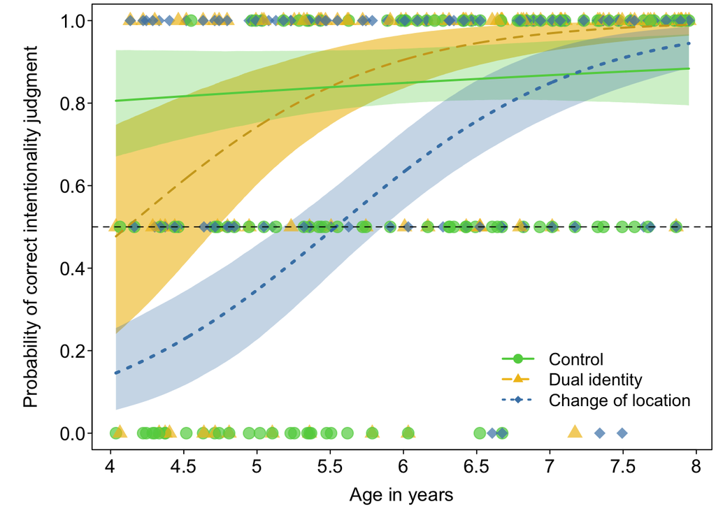

```r
# x-values
plot.xvals = seq(from = min(data_long$z_age_years), to = max(data_long$z_age_years), length.out = 1000)

# Plot settings
par(mar = c(3, 4.5, 0.2, 0.2),
    mgp = c(1.7, 0.3, 0),
    las = 1,
    tcl = -0.2)

# Create plot
min <- (min(data_long$age_years) - mean(data_long$age_years)) / sd(data_long$age_years)
plot(x = data_long$z_age_years, y = data_long$t_correct,
     pch = 19,
     las = 1,
     ylim = c(0, 1),
     xlim = c(min, max(data_long$z_age_years)),
     col = c("white"),
     xlab = "Age in years", ylab = "",
     xaxt = "n",# no x-axis
     cex.lab = 1.1,
     cex.axis = 1.1)

# Add CI for condition Dual identity
polygon(x = c(plot.xvals, rev(plot.xvals)),
        y = c(boot.res.plot$ci.predicted$lower.cl[boot.res.plot$ci.predicted$condition == "asp"],
              rev(boot.res.plot$ci.predicted$upper.cl[boot.res.plot$ci.predicted$condition == "asp"])),
        border = NA,
        col = alpha("#F0BF1B", 0.6))

# Add CI for condition Control
polygon(x = c(plot.xvals, rev(plot.xvals)),
        y = c(boot.res.plot$ci.predicted$lower.cl[boot.res.plot$ci.predicted$condition == "kon"],
              rev(boot.res.plot$ci.predicted$upper.cl[boot.res.plot$ci.predicted$condition == "kon"])),
        border = NA,
        col = alpha(3, 0.3))

# Add CI for condition Change of location
polygon(x = c(plot.xvals, rev(plot.xvals)),
        y = c(boot.res.plot$ci.predicted$lower.cl[boot.res.plot$ci.predicted$condition == "n.asp"],
              rev(boot.res.plot$ci.predicted$upper.cl[boot.res.plot$ci.predicted$condition == "n.asp"])),
        border = NA,
        col = alpha("#4682B4", 0.3))

# add dots
points(x = xx$z_age_years, y = xx$x,
       pch = c(17,19,18)[as.numeric(xx$condition)],
       las = 1,
       ylim = c(0, 1),
       col = alpha(c("#F0BF1B",3,"#4682B4"), 0.7)[as.numeric(xx$condition)],
       cex = 1.5,)

# Add line for condition Dual identity
lines(x = plot.xvals, y = boot.res.plot$ci.predicted$fitted[boot.res.plot$ci.predicted$condition == "asp"], lty = 2, lwd = 2, col = "#CEA620")

# Add line for condition Control
lines(x = plot.xvals, y = boot.res.plot$ci.predicted$fitted[boot.res.plot$ci.predicted$condition == "kon"], lty = 1, lwd = 2, col = 3)

# Add line for condition Change of location
lines(x = plot.xvals, y = boot.res.plot$ci.predicted$fitted[boot.res.plot$ci.predicted$condition == "n.asp"], lty = 3, lwd = 3, col = "#4682B4")

# Add x-axis
x.lab = c(4.0,4.5,5.0,5.5,6.0,6.5,7.0,7.5,8.0)
axis(side = 1, labels = x.lab, at = (x.lab - mean(data_long$age_years)) / sd(data_long$age_years), cex.axis = 1.1)

# Add legend
legend(x = 0.6, y = 0.23, legend = c( "Control","Dual identity", "Change of location"), col=c(3,"#F0BF1B","#4682B4"), lty = c(1,2,3), lwd = 2, pch = c(19,17,18), bty = "n", cex = 1)

# chance level
abline(h = 0.5, lty = 8)

mtext(side = 2, "Probability of correct intentionality judgment", line = 2.5, las = 3, cex = 1.1)
```

### 1.3.8 Age of onset

#### 1.3.8.1 lowest age when performance in CoL condition is above chance level

```r
age <- boot.res.plot$ci.predicted$z_age_years[boot.res.plot$ci.predicted$condition == "n.asp" & boot.res.plot$ci.predicted$lower.cl < 0.5]
lower.cl <- boot.res.plot$ci.predicted$lower.cl[boot.res.plot$ci.predicted$lower.cl < 0.5 & boot.res.plot$ci.predicted$condition == "n.asp"]
xx <- as.data.frame(cbind(age, lower.cl))
x <- max(xx$age[xx$lower.cl < 0.5])
above_chance_CoL <- x * sd(data_long$age_years) + mean(data_long$age_years) # crossing point (minimum age)
above_chance_CoL
```

```
## [1] 5.857567
```

#### 1.3.8.2 lowest age when performance in Dual identity condition is above chance level

```r
age <- boot.res.plot$ci.predicted$z_age_years[boot.res.plot$ci.predicted$condition == "asp" & boot.res.plot$ci.predicted$lower.cl < 0.5]
lower.cl <- boot.res.plot$ci.predicted$lower.cl[boot.res.plot$ci.predicted$lower.cl < 0.5 & boot.res.plot$ci.predicted$condition == "asp"]
xx <- as.data.frame(cbind(age, lower.cl))
x <- max(xx$age[xx$lower.cl < 0.5])
above_chance_DI <- x * sd(data_long$age_years) + mean(data_long$age_years) # crossing point (minimum age)
above_chance_DI
```

```
## [1] 4.721809
```

## 1.4 to wide format

```r
#data_wide_s1 <- pivot_wider(data = data_long,
#                  id_cols = c("id", "age_years", "age_years_full","z_age_years", "sex", "cb", "experimenter", "order"),
#                  names_from = c("trial","condition"),
#                  values_from = c("obj.pair", "consis", "res_c", "res_t", "c_correct", "t_correct"))
```

## 1.5 Exploratory analyses

```r
data_wide_s1 <- data_wide_s1 %>%
  mutate(sum_di = t_correct_1_dual_identity + t_correct_2_dual_identity,
         sum_col = t_correct_1_change_of_location + t_correct_2_change_of_location,
         sum_con = t_correct_1_control + t_correct_2_control)
```

```r
table(data_wide_s1$sum_di, data_wide_s1$age_years_full)
```

```
##
##      4  5  6  7
##   0  7  3  1  1
##   1  9  4  6  2
##   2 10 17 21 26
```

```r
table(data_wide_s1$sum_col, data_wide_s1$age_years_full)
```

```
##
##      4  5  6  7
##   0 14 11  3  0
##   1 10 11 12  8
##   2  3  9 17 22
```

```r
table(data_wide_s1$sum_con, data_wide_s1$age_years_full)
```

```
##
##      4  5  6  7
##   0  0  0  2  2
##   1 12  8  7  5
##   2 14 20 21 23
```

–> it looks like in the asp. condition 4-year old’s are kind of guessing, as they are closely to 33% per 0/1/2 correct answers, while they are systematically wrong in the n.asp condition –> 50% 0 answers correct, 37% 1 answer and 11% both correct

# 2 Study 2

## 2.1 Preparations

```r
#load data
df_long <- read.csv("./data/study2/test_data.csv", stringsAsFactors=TRUE)
df_fam_long <- read.csv("./data/study2/fam_data.csv", stringsAsFactors=TRUE)
df_wide_s2 <- read.csv("./data/study2/test_data_wide.csv", stringsAsFactors=TRUE)

df_long$trial.f <- as.factor(df_long$trial)

df_long$condition_ref_CoL <- relevel(df_long$condition, ref = "CoL")
df_long$belief_ref_TB <- relevel(df_long$belief, ref = "TB")
```

### 2.1.1 Exclusion

```r
dropout_abort_s2 <- sum(df_long$reason_exlusion == "study aborted", na.rm = T) # these 2 children saw only 1 full test trial
dropout_abort_s2
```

```
## [1] 2
```

```r
participated_in_s1_s2 <- sum(df_long$reason_exlusion == "participated in study 1", na.rm = T)/8 #divided by 8, because 8 full trials
participated_in_s1_s2
```

```
## [1] 1
```

```r
df_long_ex <- df_long %>%
  filter(included == "main")

dropout_fam_s2 <- length(unique(df_long$id)) - length(unique(df_long_ex$id)) - participated_in_s1_s2
dropout_fam_s2
```

```
## [1] 15
```

```r
dropout_s2 <- length(unique(df_long$id)) - length(unique(df_long_ex$id))
dropout_s2
```

```
## [1] 16
```

## 2.2 Descriptives

```r
#N
length(unique(df_long_ex$id))
```

```
## [1] 119
```

```r
mean_age_s2 <- mean(df_wide_s2$age_years)
mean_age_s2
```

```
## [1] 6.004008
```

```r
sd_age_s2 <- sd(df_wide_s2$age_years)
sd_age_s2
```

```
## [1] 1.197843
```

```r
# Z-transformation
df_long_ex$z_age_years <- as.numeric(scale(df_long_ex$age_years, center = mean_age_s2, scale = sd_age_s2))

min_age_s2 <- min(df_wide_s2$age_years)
min_age_s2
```

```
## [1] 4.010929
```

```r
max_age_s2 <- max(df_wide_s2$age_years)
max_age_s2
```

```
## [1] 8.043836
```

### 2.2.1 Probability of correct choices as a function of belief and age

```r
df_long_ex %>%
  filter(!(is.na(TQ))) %>%
  group_by(belief, age_years_full) %>%
  count(TQ) %>%
  mutate(prop = n/sum(n))%>%
  filter(TQ == "1")
```

```
## # A tibble: 10 × 5
## # Groups:   belief, age_years_full [10]
##    belief age_years_full    TQ     n  prop
##    <fct>           <int> <int> <int> <dbl>
##  1 FB                  4     1    57 0.475
##  2 FB                  5     1    67 0.578
##  3 FB                  6     1    83 0.741
##  4 FB                  7     1    90 0.776
##  5 FB                  8     1     4 1
##  6 TB                  4     1   103 0.844
##  7 TB                  5     1   100 0.862
##  8 TB                  6     1    97 0.866
##  9 TB                  7     1   107 0.922
## 10 TB                  8     1     4 1
```

### 2.2.2 Probability of correct choices as a function of belief, condition and age

```r
plot_prop <- df_long_ex %>%
  filter(!(is.na(TQ))) %>%
  group_by(belief, condition, age_years_full) %>%
  count(TQ) %>%
  mutate(prop = n/sum(n))%>%
  filter(TQ == "1")

plot_prop
```

```
## # A tibble: 20 × 6
## # Groups:   belief, condition, age_years_full [20]
##    belief condition age_years_full    TQ     n  prop
##    <fct>  <fct>              <int> <int> <int> <dbl>
##  1 FB     asp                    4     1    28 0.467
##  2 FB     asp                    5     1    37 0.638
##  3 FB     asp                    6     1    43 0.768
##  4 FB     asp                    7     1    44 0.759
##  5 FB     asp                    8     1     2 1
##  6 FB     CoL                    4     1    29 0.483
##  7 FB     CoL                    5     1    30 0.517
##  8 FB     CoL                    6     1    40 0.714
##  9 FB     CoL                    7     1    46 0.793
## 10 FB     CoL                    8     1     2 1
## 11 TB     asp                    4     1    52 0.839
## 12 TB     asp                    5     1    48 0.828
## 13 TB     asp                    6     1    47 0.839
## 14 TB     asp                    7     1    53 0.914
## 15 TB     asp                    8     1     2 1
## 16 TB     CoL                    4     1    51 0.85
## 17 TB     CoL                    5     1    52 0.897
## 18 TB     CoL                    6     1    50 0.893
## 19 TB     CoL                    7     1    54 0.931
## 20 TB     CoL                    8     1     2 1
```

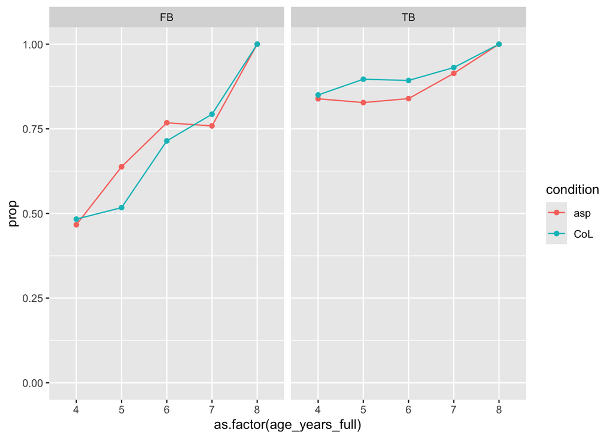

```r
ggplot(data = plot_prop, aes(x = as.factor(age_years_full), y = prop, group = condition, color = condition)) +
  geom_point(aes(group = condition)) +
  geom_line(aes(group = condition)) +
  ylim(0,1)+
  facet_wrap(~belief)
```

```r
# as a table
correct.choice.s2 <- df_long_ex %>%
  filter(!is.na(TQ)) %>%
  group_by(belief, condition_ref_CoL, age_years_full) %>%
  summarise(prop = mean(TQ == "1")) %>%
  mutate(across(where(is.numeric), ~round(., 2))) %>%
  pivot_wider(names_from = c("belief", "condition_ref_CoL"), values_from = prop, values_fill = 0)
correct.choice.s2$age_years_full[1] <- paste0(correct.choice.s2$age_years_full[1], " (n = ", table(df_wide_s2$age_years_full)[1], ")")
correct.choice.s2$age_years_full[2] <- paste0(correct.choice.s2$age_years_full[2], " (n = ", table(df_wide_s2$age_years_full)[2], ")")
correct.choice.s2$age_years_full[3] <- paste0(correct.choice.s2$age_years_full[3], " (n = ", table(df_wide_s2$age_years_full)[3], ")")
correct.choice.s2$age_years_full[4] <- paste0(correct.choice.s2$age_years_full[4], " (n = ", table(df_wide_s2$age_years_full)[4], ")")
correct.choice.s2$age_years_full[5] <- paste0(correct.choice.s2$age_years_full[5], " (n = ", table(df_wide_s2$age_years_full)[5], ")")

kable(correct.choice.s2, "html",
      booktabs = T,
      escape = F,
      align = c(rep("c")),
      caption = "Probability of correct intentionality judgments per age groups, belief manipulation, and conditions",
      col.names = c("Age in years","Change of location","Dual identity", "Change of location","Dual identity")) %>%
  add_header_above(c(" " = 1, "False belief" = 2, "True belief" = 2)) %>%
  kable_styling(full_width = T)
```

Table 2.1: Probability of correct intentionality judgments per age groups, belief manipulation, and conditions

| Age in years | False belief Change of location | False belief Dual identity | True belief Change of location | True belief Dual identity |
| --- | --- | --- | --- | --- |
| 4 (n = 32) | 0.48 | 0.47 | 0.85 | 0.84 |
| 5 (n = 29) | 0.52 | 0.64 | 0.90 | 0.83 |
| 6 (n = 28) | 0.71 | 0.77 | 0.89 | 0.84 |
| 7 (n = 29) | 0.79 | 0.76 | 0.93 | 0.91 |
| 8 (n = 1) | 1.00 | 1.00 | 1.00 | 1.00 |

```r
df_long_ex$age_years_full[df_long_ex$id == 146] <- 7

correct.choice.s2 <- df_long_ex %>%
  filter(!is.na(TQ)) %>%
  group_by(belief_ref_TB, condition_ref_CoL, age_years_full) %>%
  summarise(prop = mean(TQ == "1"), .groups = "drop") %>%
  mutate(prop = round(prop * 100)) %>%  # convert to percentage
  pivot_wider(names_from = c("belief_ref_TB", "condition_ref_CoL"), values_from = prop, values_fill = 0)

correct.choice.s2$age_years_full[1] <- paste0(correct.choice.s2$age_years_full[1], " ($n$ = ", table(df_wide_s2$age_years_full)[1], ")")
correct.choice.s2$age_years_full[2] <- paste0(correct.choice.s2$age_years_full[2], " ($n$ = ", table(df_wide_s2$age_years_full)[2], ")")
correct.choice.s2$age_years_full[3] <- paste0(correct.choice.s2$age_years_full[3], " ($n$ = ", table(df_wide_s2$age_years_full)[3], ")")
correct.choice.s2$age_years_full[4] <- paste0(correct.choice.s2$age_years_full[4], " ($n$ = ", table(df_wide_s2$age_years_full)[4]+1, ")") # adding the 8 year old

df_long_ex$age_years_full[df_long_ex$id == 146] <- 8
```

##### 2.2.2.0.1 Probability of correct choices in consistent trials as a function of belief, condition and age

```r
consis_s2 <- df_long_ex %>%
  filter(!is.na(TQ)) %>%
  group_by(consis) %>%
  summarise(prop = mean(TQ == "1")) %>%
  mutate(across(where(is.numeric), ~round(., 3)))
consis_s2
```

```
## # A tibble: 2 × 2
##   consis  prop
##   <fct>  <dbl>
## 1 C      0.692
## 2 I      0.826
```

```r
plot_prop_consis_C <- df_long_ex %>%
  filter(consis == "C") %>%
  filter(!(is.na(TQ))) %>%
  group_by(belief, condition, age_years_full) %>%
  count(TQ) %>%
  mutate(prop = n/sum(n))%>%
  filter(TQ == "1")

plot_prop_consis_C
```

```
## # A tibble: 20 × 6
## # Groups:   belief, condition, age_years_full [20]
##    belief condition age_years_full    TQ     n  prop
##    <fct>  <fct>              <dbl> <int> <int> <dbl>
##  1 FB     asp                    4     1    10 0.333
##  2 FB     asp                    5     1    15 0.517
##  3 FB     asp                    6     1    20 0.714
##  4 FB     asp                    7     1    21 0.724
##  5 FB     asp                    8     1     1 1
##  6 FB     CoL                    4     1     9 0.3
##  7 FB     CoL                    5     1    14 0.483
##  8 FB     CoL                    6     1    19 0.679
##  9 FB     CoL                    7     1    21 0.724
## 10 FB     CoL                    8     1     1 1
## 11 TB     asp                    4     1    23 0.767
## 12 TB     asp                    5     1    22 0.759
## 13 TB     asp                    6     1    22 0.786
## 14 TB     asp                    7     1    26 0.897
## 15 TB     asp                    8     1     1 1
## 16 TB     CoL                    4     1    25 0.833
## 17 TB     CoL                    5     1    24 0.828
## 18 TB     CoL                    6     1    23 0.821
## 19 TB     CoL                    7     1    26 0.897
## 20 TB     CoL                    8     1     1 1
```

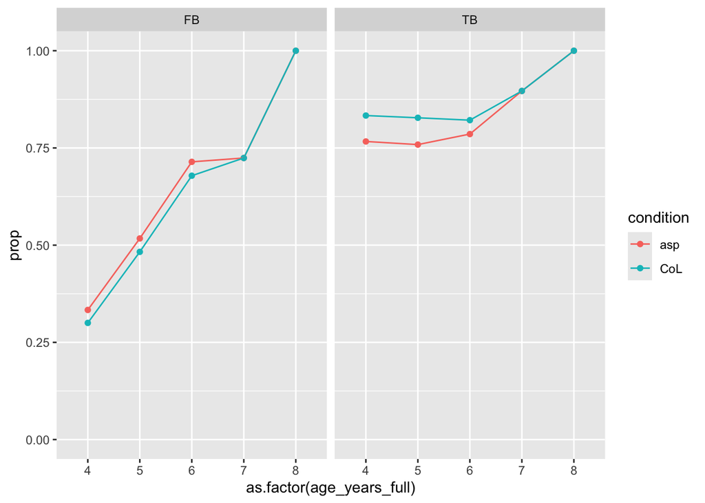

```r
ggplot(data = plot_prop_consis_C, aes(x = as.factor(age_years_full), y = prop, group = condition, color = condition)) +
  geom_point(aes(group = condition)) +
  geom_line(aes(group = condition)) +
  ylim(0,1)+
  facet_wrap(~belief)
```

##### 2.2.2.0.2 Probability of correct choices in inconsistent trials as a function of belief, condition and age

```r
plot_prop_consis_I <- df_long_ex %>%
  filter(consis == "I") %>%
  filter(!(is.na(TQ))) %>%
  group_by(belief, condition, age_years_full) %>%
  count(TQ) %>%
  mutate(prop = n/sum(n))%>%
  filter(TQ == "1")

plot_prop_consis_I
```

```
## # A tibble: 20 × 6
## # Groups:   belief, condition, age_years_full [20]
##    belief condition age_years_full    TQ     n  prop
##    <fct>  <fct>              <dbl> <int> <int> <dbl>
##  1 FB     asp                    4     1    18 0.6
##  2 FB     asp                    5     1    22 0.759
##  3 FB     asp                    6     1    23 0.821
##  4 FB     asp                    7     1    23 0.793
##  5 FB     asp                    8     1     1 1
##  6 FB     CoL                    4     1    20 0.667
##  7 FB     CoL                    5     1    16 0.552
##  8 FB     CoL                    6     1    21 0.75
##  9 FB     CoL                    7     1    25 0.862
## 10 FB     CoL                    8     1     1 1
## 11 TB     asp                    4     1    29 0.906
## 12 TB     asp                    5     1    26 0.897
## 13 TB     asp                    6     1    25 0.893
## 14 TB     asp                    7     1    27 0.931
## 15 TB     asp                    8     1     1 1
## 16 TB     CoL                    4     1    26 0.867
## 17 TB     CoL                    5     1    28 0.966
## 18 TB     CoL                    6     1    27 0.964
## 19 TB     CoL                    7     1    28 0.966
## 20 TB     CoL                    8     1     1 1
```

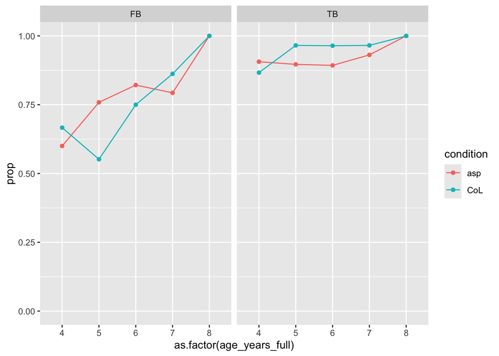

```r
ggplot(data = plot_prop_consis_I, aes(x = as.factor(age_years_full), y = prop, group = condition, color = condition)) +
  geom_point(aes(group = condition)) +
  geom_line(aes(group = condition)) +
  ylim(0,1)+
  facet_wrap(~belief)
```

```r
# as a table
correct.choice.ci.s2 <- df_long_ex %>%
  filter(!is.na(TQ)) %>%
  group_by(belief, consis, age_years_full) %>%
  summarise(prop = mean(TQ == "1")) %>%
  mutate(across(where(is.numeric), ~round(., 2))) %>%
  pivot_wider(names_from = c("consis", "belief"), values_from = prop, values_fill = 0)
correct.choice.ci.s2$age_years_full[1] <- paste0(correct.choice.ci.s2$age_years_full[1], " (n = ", table(df_wide_s2$age_years_full)[1], ")")
correct.choice.ci.s2$age_years_full[2] <- paste0(correct.choice.ci.s2$age_years_full[2], " (n = ", table(df_wide_s2$age_years_full)[2], ")")
correct.choice.ci.s2$age_years_full[3] <- paste0(correct.choice.ci.s2$age_years_full[3], " (n = ", table(df_wide_s2$age_years_full)[3], ")")
correct.choice.ci.s2$age_years_full[4] <- paste0(correct.choice.ci.s2$age_years_full[4], " (n = ", table(df_wide_s2$age_years_full)[4], ")")
correct.choice.ci.s2$age_years_full[5] <- paste0(correct.choice.ci.s2$age_years_full[5], " (n = ", table(df_wide_s2$age_years_full)[5], ")")

kable(correct.choice.ci.s2, "html",
      booktabs = T,
      escape = F,
      align = c(rep("c")),
      caption = "Probability of correct intentionality judgments per age groups, belief manipulation, and conditions",
      col.names = c("Age in years","Consistent","Inconsistent", "Consistent","Inconsistent")) %>%
  add_header_above(c(" " = 1, "False belief" = 2, "True belief" = 2)) %>%
  kable_styling(full_width = T)
```

Table 2.2: Probability of correct intentionality judgments per age groups, belief manipulation, and conditions

| Age in years | False belief Consistent | False belief Inconsistent | True belief Consistent | True belief Inconsistent |
| --- | --- | --- | --- | --- |
| 4 (n = 32) | 0.32 | 0.63 | 0.80 | 0.89 |
| 5 (n = 29) | 0.50 | 0.66 | 0.79 | 0.93 |
| 6 (n = 28) | 0.70 | 0.79 | 0.80 | 0.93 |
| 7 (n = 29) | 0.72 | 0.83 | 0.90 | 0.95 |
| 8 (n = 1) | 1.00 | 1.00 | 1.00 | 1.00 |

### 2.2.3 Plot: raw responses as a function of condition, belief and age groups

One child was already 8 years when conducting the study. To simplify visualization, the age (in full years) of this child has been reset to 7.

```r
df_long_ex$age_years_full[df_long_ex$id == 146] <- 7
df_wide_s2$age_years_full[df_wide_s2$id == 146] <- 7
```

```r
raw_responses_s2 <- df_long_ex %>%
  group_by(age_years_full, belief_ref_TB, condition_ref_CoL, consis) %>%
  count(res_t) %>%
  filter(!is.na(res_t)) %>%
  mutate(percentage = n / sum(n) * 100)

raw_responses_s2$res_t <- factor(raw_responses_s2$res_t, labels = c("self", "wind"))
raw_responses_s2$consis <- factor(raw_responses_s2$consis, labels = c("C", "I"))
```

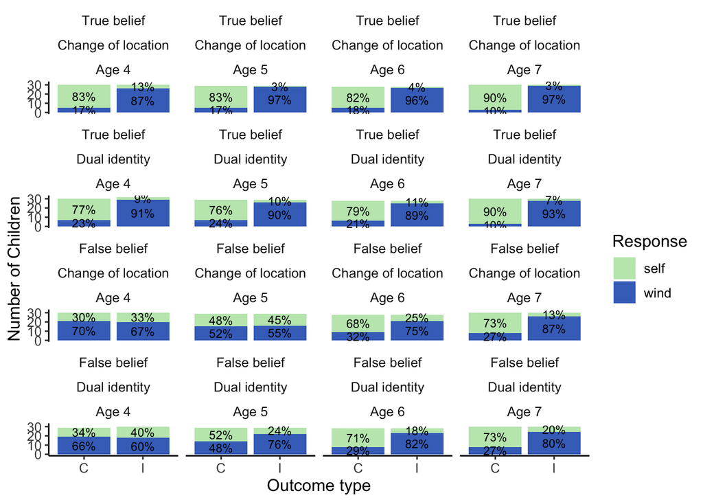

```r
# Plot
ggplot(data = raw_responses_s2, aes(fill = res_t, y = n, x = consis)) +
  geom_bar(stat = "identity") +
  geom_text(aes(label = paste0(round(percentage), "%")),
            position = position_stack(vjust = 0.5), size = 3, color = "black") +  # Add data labels
  labs(fill = "Response") +
  xlab("Outcome type") +
  ylab("Number of Children") +
  scale_fill_manual(values = c("#c1e7bb", "#4472C4")) +
  facet_wrap(~belief_ref_TB + condition_ref_CoL + age_years_full,
             labeller = labeller(belief_ref_TB = c("TB" = "True belief", "FB" = "False belief"),
                                   condition_ref_CoL = c("CoL" = "Change of location", "asp" = "Dual identity"),
                                 age_years_full = c("4" = "Age 4", "5" = "Age 5", "6" = "Age 6", "7" = "Age 7"))
             ) +
  theme_classic() +
  theme(panel.grid.major = element_blank(),
        panel.background = element_blank(),
        panel.grid.minor = element_blank(),
        axis.line = element_line(colour = "black"),
        text = element_text(size = 12),
        #strip.text.x = element_blank(),  # Remove x-axis facet labels
        strip.background = element_blank())  # Remove background for facet labels
```

```r
svg(file = "plots/raw_res_s2.svg", width = 7, height = 8)
pdf(file = "plots/raw_res_s2.pdf", width = 7, height = 8)
# Change the reference group for the res_t factor
raw_responses_s2$res_t <- factor(raw_responses_s2$res_t, levels = c("wind", "self"))

# Define colors
colors <- c("#4472C4", "#c1e7bb")  # Corresponding to "wind" and "self"

# Split data by facets
facets <- split(raw_responses_s2, list(raw_responses_s2$condition_ref_CoL, raw_responses_s2$belief_ref_TB))

# Set up the plotting area with multiple facets and ensure enough space for the custom label
par(mfrow = c(4, 4), mar = c(2, 2, 2, 1), oma = c(5, 4, 2, 2))  # Adjusted outer margin (oma)

ages <- unique(raw_responses_s2$age_years_full)

# Create plots
for(i in seq_along(facets)) {
  for(age in ages) {
    data <- facets[[i]]
    data <- data[data$age_years_full == age,]

    # Create barplot
    bar_heights <- tapply(data$n, list(data$res_t, data$consis), sum)
    bar_labels <- tapply(data$percentage, list(data$res_t, data$consis), function(x) paste0(round(x), "%"))

    barplot_heights <- barplot(
      height = bar_heights,
      beside = FALSE,
      border = NA,  # Remove black borders around bars
      col = colors,
      ylim = c(0, max(raw_responses_s2$n) + 10),
      xlab = "",
      ylab = "",
      main = "",
      cex.axis = 1.2,
      cex.names = 1.2
    )

    # Add text labels
    cumulative_height <- apply(bar_heights, 2, cumsum)
    midpoints <- barplot_heights

    for (j in 1:ncol(bar_heights)) {
      for (k in 1:nrow(bar_heights)) {
        # Only add label if percentage is 10% or higher
        if (as.numeric(sub("%", "", bar_labels[k, j])) >= 10) {
          text(
            x = midpoints[j],
            y = cumulative_height[k, j] - bar_heights[k, j] / 2,
            labels = bar_labels[k, j],
            cex = 1.1,
            col = "black"
          )
        }
      }
    }
  }
}

# Centered age labels below each row of plots
mtext(text = "Age", side = 1, line = 3, outer = TRUE, at = 0, cex = 1.2)
mtext(text = ages[1], side = 1, line = 3, outer = TRUE, at = 0.135, cex = 1.2)
mtext(text = ages[2], side = 1, line = 3, outer = TRUE, at = 0.39, cex = 1.2)
mtext(text = ages[3], side = 1, line = 3, outer = TRUE, at = 0.64, cex = 1.2)
mtext(text = ages[4], side = 1, line = 3, outer = TRUE, at = 0.89, cex = 1.2)
mtext(text = "Outcome type", side = 1, line = 1, outer = TRUE, at = 0.5, cex = 1, las = 0)

# Add "True Belief" and "False Belief" labels to the left side
mtext(text = "True Belief", side = 2, line = 2, outer = TRUE, at = 0.75, cex = 1.2, las = 0)
mtext(text = "False Belief", side = 2, line = 2, outer = TRUE, at = 0.25, cex = 1.2, las = 0)

mtext(text = "Number of Children", side = 2, line = 1, outer = TRUE, at = 0.5, cex = 1, las = 0)

# Add "Change of location" and "Dual Identity" labels above the columns
mtext(text = "Change of location", side = 3, line = -2, outer = TRUE, at = 0.5, cex = 1.2, las = 0)
mtext(text = "Dual Identity", side = 3, line = -16, outer = TRUE, at = 0.5, cex = 1.2, las = 0)
mtext(text = "Change of location", side = 3, line = -29, outer = TRUE, at = 0.5, cex = 1.2, las = 0)
mtext(text = "Dual Identity", side = 3, line = -42, outer = TRUE, at = 0.5, cex = 1.2, las = 0)
```

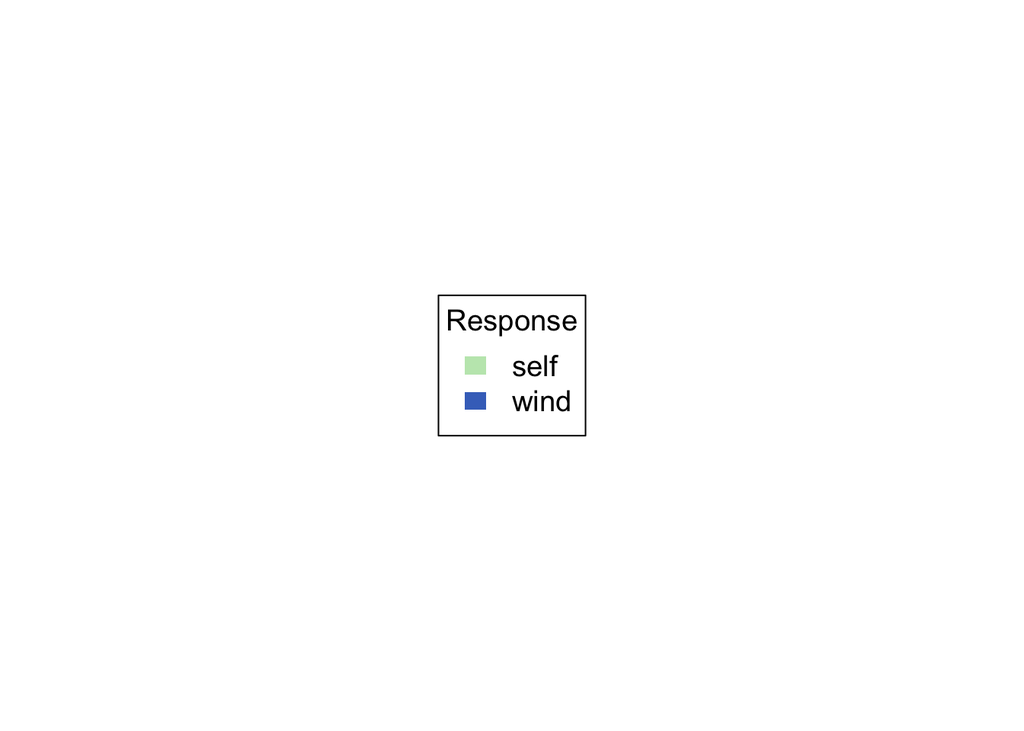

```r
par(mfrow = c(1, 1),
    mar = c(0, 0, 0, 0),   # Set smaller margins around the plot
    oma = c(0, 0, 0, 0))   # Reduce or remove outer margins if not needed

colors <- c("#c1e7bb","#4472C4")  # Corresponding to "wind" and "self"
res_t <- c("self", "wind")
# Add legend on the right side
plot.new()
legend("center",   # Adjust inset to move the legend outside the plot area
       legend=res_t,
       fill=colors,
       border = NA,
       title="Response",  # Title for the legend
       cex=1.2, xpd = TRUE)  # Adjust text size as needed
```

```r
pdf(file = "plots/raw_res_s2_v2.pdf", width = 7, height = 8)
# Change the reference group for the res_t factor
raw_responses_s2$res_t <- factor(raw_responses_s2$res_t, levels = c("wind", "self"))

# Define colors
colors <- c("#4472C4", "#c1e7bb")  # Corresponding to "wind" and "self"

# Split data by facets
facets <- split(raw_responses_s2, list(raw_responses_s2$condition_ref_CoL, raw_responses_s2$belief_ref_TB))

# Set up the plotting area with multiple facets and ensure enough space for the custom label
ages <- unique(raw_responses_s2$age_years_full)

par(mfrow = c(4, 4), mar = c(2, 2, 3, 1), oma = c(6, 4, 2, 2))  # Adjusted outer margin (oma)

plot_index <- 0  # initialize plot counter

for (i in seq_along(facets)) {
  for (age in ages) {
    plot_index <- plot_index + 1  # increment for each subplot

    data <- facets[[i]]
    data <- data[data$age_years_full == age, ]

    # Create barplot
    bar_heights <- tapply(data$n, list(data$res_t, data$consis), sum)
    bar_labels <- tapply(data$percentage, list(data$res_t, data$consis), function(x) paste0(round(x), "%"))

    barplot_heights <- barplot(
      height = bar_heights,
      beside = FALSE,
      border = NA,
      col = colors,
      ylim = c(0, max(raw_responses$n) + 5),
      xlab = "",
      ylab = "",
      main = "",
      cex.names = 1.2,
      yaxt = "n"
    )

    axis(2, at = seq(0, max(raw_responses$n) + 5, by = 10), las = 1, cex.axis = 1.2)

    cumulative_height <- apply(bar_heights, 2, cumsum)
    midpoints <- barplot_heights

    for (j in 1:ncol(bar_heights)) {
      for (k in 1:nrow(bar_heights)) {
        if (as.numeric(sub("%", "", bar_labels[k, j])) >= 10) {
          text(
            x = midpoints[j],
            y = cumulative_height[k, j] - bar_heights[k, j] / 2,
            labels = bar_labels[k, j],
            cex = 1.1,
            col = "black"
          )
        }
      }
    }

    if (plot_index >= 13) {
      center_x <- mean(barplot_heights)
      text(x = center_x, y = -24, labels = paste(age),
           xpd = NA, cex = 1.8)
    }
  }
}

mtext(text = "Age", side = 1, line = 3.5, outer = TRUE, at = 0, cex = 1.2)
mtext(text = "Number of Children", side = 2, line = 1, outer = TRUE, at = 0.5, cex = 1, las = 0)
mtext(text = "Outcome type", side = 1, line = 1, outer = TRUE, at = 0.5, cex = 1, las = 0)

# Add "True Belief" and "False Belief" labels to the left side
mtext(text = "True Belief", side = 2, line = 2, outer = TRUE, at = 0.75, cex = 1.2, las = 0)
mtext(text = "False Belief", side = 2, line = 2, outer = TRUE, at = 0.25, cex = 1.2, las = 0)

# Add "Change of location" and "Dual Identity" labels above the columns
mtext(text = "Change of location", side = 3, line = -2, outer = TRUE, at = 0.5, cex = 1.2, las = 0)
mtext(text = "Dual Identity", side = 3, line = -16, outer = TRUE, at = 0.5, cex = 1.2, las = 0)
mtext(text = "Change of location", side = 3, line = -29, outer = TRUE, at = 0.5, cex = 1.2, las = 0)
mtext(text = "Dual Identity", side = 3, line = -42, outer = TRUE, at = 0.5, cex = 1.2, las = 0)


# Allow drawing outside plots
par(xpd = NA)

# Convert normalized positions to user coordinates
x_left  <- grconvertX(0.12, from = "ndc", to = "user")
x_right <- grconvertX(0.94, from = "ndc", to = "user")
y_line  <- grconvertY(0.05, from = "ndc", to = "user")  # adjust to hover just above age labels

# Draw the horizontal line
segments(x0 = x_left, y0 = y_line, x1 = x_right, y1 = y_line, lwd = 1)

# Normalized x positions for age labels
age_ndc_positions <- c(0.199, 0.42, 0.64, 0.86)

# Convert to user coordinates
age_tick_x <- grconvertX(age_ndc_positions, from = "ndc", to = "user")

# Set vertical range of each tick
tick_y_bottom <- y_line - 0.5  # slightly below the line
tick_y_top <- y_line + 0.5     # slightly above the line

# Draw the ticks
segments(x0 = age_tick_x, y0 = tick_y_bottom, x1 = age_tick_x, y1 = tick_y_top, lwd = 1)

dev.off()
```

## 2.3 Statisitcal analyses

### 2.3.1 fit null model

```r
null_s2 = glmer(TQ ~ z_age_years + trial.f + consis + (1+belief+condition+consis|id) + (1|experimenter),
                 family = "binomial",
                 data = df_long_ex,
             control = glmerControl(optimizer = "bobyqa", optCtrl = list(maxfun = 100000)))
```

```
## boundary (singular) fit: see help('isSingular')
```

```r
red_s2 = glmer(TQ ~ belief + z_age_years + condition + trial.f + consis +  (1+belief+condition+consis|id)  + (1|experimenter),
                 family = "binomial",
                 data = df_long_ex,
            control = glmerControl(optimizer = "bobyqa", optCtrl = list(maxfun = 100000)))
```

```
## boundary (singular) fit: see help('isSingular')
```

### 2.3.2 fit full model

```r
full_s2 = glmer(TQ ~ belief * z_age_years + condition + trial.f + consis +
                  (1+belief+condition+consis|id) +
                  (1|experimenter),
                 family = "binomial",
                 data = df_long_ex,
             control = glmerControl(optimizer = "bobyqa", optCtrl = list(maxfun = 100000)))
```

```
## boundary (singular) fit: see help('isSingular')
```

### 2.3.3 model comparison

```r
as.data.frame(anova(null_s2, full_s2, test="Chisq"))
```

```
##         npar      AIC      BIC    logLik deviance    Chisq Df   Pr(>Chisq)
## null_s2   15 905.5354 978.1917 -437.7677 875.5354       NA NA           NA
## full_s2   18 868.9552 956.1427 -416.4776 832.9552 42.58025  3 3.021503e-09
```

#### 2.3.3.1 Test assumptions

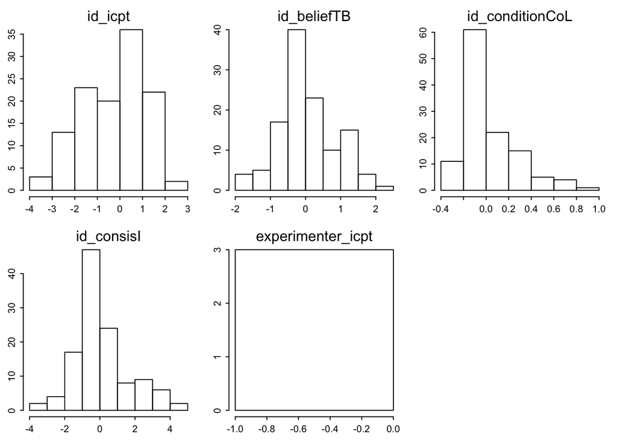

```r
# Normal distribution of random effects
ranef.diagn.plot(full_s2)
```

```r
# Model stability
m.stab.s2 = glmm.model.stab(model.res = full_s2, para = T)

saveRDS(m.stab.s2, file = "workspaces/PIntenWi_m_stab_s2.RData")
```

```r
round(m.stab.s2$summary[, -1], 3)
m.stab.plot(m.stab.s2$summary[, -1])
```

```r
# Collinearity
full.coll.s2 <- glmer(TQ ~ condition + z_age_years + belief + trial.f + consis +  (1+belief+condition+consis|id) + (1|experimenter),
                   data = df_long_ex,
                   family = binomial,
                   control = glmerControl(optimizer = "bobyqa", optCtrl = list(maxfun = 100000))) # model without interaction
```

```
## boundary (singular) fit: see help('isSingular')
```

```r
car::vif(full.coll.s2)
```

```
##   condition z_age_years      belief     trial.f      consis
##    1.008803    1.095676    1.082830    1.002956    1.021777
```

```r
# Overdispersion
overdisp.test(full_s2)
```

```
##      chisq  df P dispersion.parameter
## 1 446.0928 920 1            0.4848835
```

### 2.3.4 Model results

```r
summary(full_s2)
```

```
## Generalized linear mixed model fit by maximum likelihood (Laplace
##   Approximation) [glmerMod]
##  Family: binomial  ( logit )
## Formula: TQ ~ belief * z_age_years + condition + trial.f + consis + (1 +
##     belief + condition + consis | id) + (1 | experimenter)
##    Data: df_long_ex
## Control: glmerControl(optimizer = "bobyqa", optCtrl = list(maxfun = 1e+05))
##
##      AIC      BIC   logLik deviance df.resid
##    869.0    956.1   -416.5    833.0      920
##
## Scaled residuals:
##     Min      1Q  Median      3Q     Max
## -4.1911  0.1114  0.2035  0.3326  1.4375
##
## Random effects:
##  Groups       Name         Variance Std.Dev. Corr
##  id           (Intercept)  4.241    2.0593
##               beliefTB     2.113    1.4538   -0.31
##               conditionCoL 0.260    0.5099   -0.27 -0.62
##               consisI      5.871    2.4229   -0.70 -0.21  0.18
##  experimenter (Intercept)  0.000    0.0000
## Number of obs: 938, groups:  id, 119; experimenter, 3
##
## Fixed effects:
##                      Estimate Std. Error z value Pr(>|z|)
## (Intercept)           0.74196    0.31892   2.326   0.0200 *
## beliefTB              1.83761    0.32442   5.664 1.48e-08 ***
## z_age_years           0.98462    0.21713   4.535 5.77e-06 ***
## conditionCoL         -0.05299    0.23113  -0.229   0.8187
## trial.f2             -0.29595    0.20550  -1.440   0.1498
## consisI               0.95753    0.36275   2.640   0.0083 **
## beliefTB:z_age_years -0.58110    0.28032  -2.073   0.0382 *
## ---
## Signif. codes:  0 '***' 0.001 '**' 0.01 '*' 0.05 '.' 0.1 ' ' 1
##
## Correlation of Fixed Effects:
##             (Intr) belfTB z_g_yr cndtCL trl.f2 conssI
## beliefTB    -0.243
## z_age_years  0.133 -0.006
## conditionCL -0.406 -0.099 -0.050
## trial.f2    -0.341 -0.039 -0.046 -0.010
## consisI     -0.500  0.017  0.149  0.013 -0.022
## blfTB:z_g_y -0.102  0.128 -0.654  0.046  0.023 -0.061
## optimizer (bobyqa) convergence code: 0 (OK)
## boundary (singular) fit: see help('isSingular')
```

```r
# Confidence intervals
boot.res.s2 = boot.glmm.pred(model.res = full_s2, excl.warnings = T, nboots = 1000, para = T)

saveRDS(boot.res.s2, file = "workspaces/PIntenWi_boot_m2.RData")
```

```r
# for Eva
# Confidence intervals
model_eva <- glmer(TQ ~ belief * z_age_years + condition + (1+belief|id),
                   data = df_long_ex,
                   family = binomial,
                   control = glmerControl(optimizer = "bobyqa", optCtrl = list(maxfun = 100000)))

summary(model_eva)

boot.res.eva = boot.glmm.pred(model.res = model_eva, excl.warnings = T, nboots = 1000, para = T)

saveRDS(boot.res.s2, file = "workspaces/PIntenWi_boot_eva.RData")
```

```r
# save model results in data frame
table.model.2 <- tibble(coefs = c("(Intercept)", "beliefTB",
                             "z_age_years","conditionCoL", "trial.f2","consisI",
                             "beliefTB:z_age_years"),
                      estimate = c(summary(full_s2)$coefficients[,1]),
                      SE = c(summary(full_s2)$coefficients[,2]),
                      z = c(summary(full_s2)$coefficients[,3]),
                      boot_lower = boot.res.s2[["ci.estimates"]][["X2.5."]],
                      boot_upper = boot.res.s2[["ci.estimates"]][["X97.5."]],
                      OR = exp(estimate),
                      p = c(summary(full_s2)$coefficients[,4]))

table.model.2[,2:6] <- round(table.model.2[,2:6],3)

table.model.2$p <- printp(table.model.2$p)

table.model.2
```

```
## # A tibble: 7 × 8
##   coefs                estimate    SE      z boot_lower boot_upper    OR p
##   <chr>                   <dbl> <dbl>  <dbl>      <dbl>      <dbl> <dbl> <chr>
## 1 (Intercept)             0.742 0.319  2.33       0.096      1.6   2.10  .020
## 2 beliefTB                1.84  0.324  5.66       1.31       3.04  6.28  < .001
## 3 z_age_years             0.985 0.217  4.54       0.585      1.68  2.68  < .001
## 4 conditionCoL           -0.053 0.231 -0.229     -0.534      0.448 0.948 .819
## 5 trial.f2               -0.296 0.206 -1.44      -0.76       0.105 0.744 .150
## 6 consisI                 0.958 0.363  2.64       0.312      2.10  2.61  .008
## 7 beliefTB:z_age_years   -0.581 0.28  -2.07      -1.35      -0.032 0.559 .038
```

#### 2.3.4.1 Bootstrapping

```r
#Model for the plot - simplified
plot.res.s2 = glmer(TQ ~ belief * z_age_years +
                      (1+belief+consis|id) +
                      (1|experimenter),
                 family = "binomial",
                 data = df_long_ex,
                 control = glmerControl(optimizer = "bobyqa", optCtrl = list(maxfun = 100000)))
```

```
## boundary (singular) fit: see help('isSingular')
```

```r
summary(plot.res.s2)
```

```
## Generalized linear mixed model fit by maximum likelihood (Laplace
##   Approximation) [glmerMod]
##  Family: binomial  ( logit )
## Formula: TQ ~ belief * z_age_years + (1 + belief + consis | id) + (1 |
##     experimenter)
##    Data: df_long_ex
## Control: glmerControl(optimizer = "bobyqa", optCtrl = list(maxfun = 1e+05))
##
##      AIC      BIC   logLik deviance df.resid
##    866.3    919.5   -422.1    844.3      927
##
## Scaled residuals:
##     Min      1Q  Median      3Q     Max
## -3.9753  0.1131  0.2231  0.3329  1.4559
##
## Random effects:
##  Groups       Name        Variance Std.Dev. Corr
##  id           (Intercept) 4.747    2.179
##               beliefTB    1.791    1.338    -0.34
##               consisI     6.077    2.465    -0.80 -0.18
##  experimenter (Intercept) 0.000    0.000
## Number of obs: 938, groups:  id, 119; experimenter, 3
##
## Fixed effects:
##                      Estimate Std. Error z value Pr(>|z|)
## (Intercept)            1.0916     0.2093   5.214 1.84e-07 ***
## beliefTB               1.7998     0.3423   5.258 1.46e-07 ***
## z_age_years            0.9158     0.2052   4.464 8.06e-06 ***
## beliefTB:z_age_years  -0.5509     0.2689  -2.049   0.0405 *
## ---
## Signif. codes:  0 '***' 0.001 '**' 0.01 '*' 0.05 '.' 0.1 ' ' 1
##
## Correlation of Fixed Effects:
##             (Intr) belfTB z_g_yr
## beliefTB    -0.386
## z_age_years  0.224  0.006
## blfTB:z_g_y -0.136  0.125 -0.649
## optimizer (bobyqa) convergence code: 0 (OK)
## boundary (singular) fit: see help('isSingular')
```

```r
timeStart<-Sys.time()

# Fitted values + CIs
boot.res.plot.s2 = boot.glmm.pred(model.res = plot.res.s2,
                               excl.warnings = F,
                               nboots = 10000,
                               para = T,
                               resol = 1000,
                               level = 0.95,
                               use = c("z_age_years", "belief"))

timeEnd<-Sys.time()

difftime(timeEnd, timeStart)

saveRDS(boot.res.plot.s2, file = "workspaces/PIntenWi_boot_plot_s2.RData")
```

### 2.3.5 Plot: correct response as a function of age and belief

```r
#Define variables
vars = c("belief", "z_age_years", "id")

# calculate probabilities for each age per condition
xx = aggregate(x = as.numeric(as.character(df_long_ex$TQ)), by = df_long_ex[, vars], FUN = mean)
```

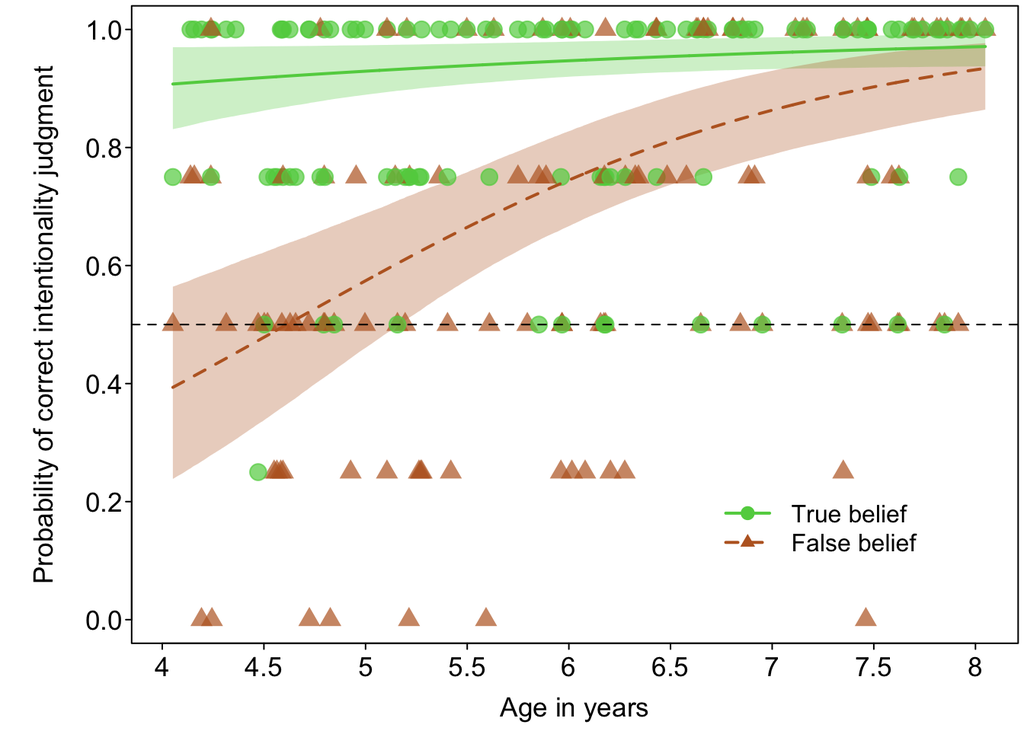

```r
# x-values
plot.xvals = seq(from = min(df_long_ex$z_age_years), to = max(df_long_ex$z_age_years), length.out = 1000)

# Plot settings
par(mar = c(3, 4.5, 0.2, 0.2),
    mgp = c(1.7, 0.3, 0),
    las = 1,
    tcl = -0.2)

# Create plot
min <- (min(df_long_ex$age_years) - mean(df_long_ex$age_years)) / sd(df_long_ex$age_years)
plot(x = df_long_ex$z_age_years, y = df_long_ex$TQ,
     pch = 19,
     las = 1,
     ylim = c(0, 1),
     xlim = c(min, max(df_long_ex$z_age_years)),
     col = c("white"),
     xlab = "Age in years", ylab = "",
     xaxt = "n",# no x-axis
     cex.lab = 1.1,
     cex.axis = 1.1)

# Add CI for True belief
polygon(x = c(plot.xvals, rev(plot.xvals)),
        y = c(boot.res.plot.s2$ci.predicted$lower.cl[boot.res.plot.s2$ci.predicted$belief == "TB"],
              rev(boot.res.plot.s2$ci.predicted$upper.cl[boot.res.plot.s2$ci.predicted$belief == "TB"])),
        border = NA,
        col = alpha(3, 0.3))

# Add CI for False belief
polygon(x = c(plot.xvals, rev(plot.xvals)),
        y = c(boot.res.plot.s2$ci.predicted$lower.cl[boot.res.plot.s2$ci.predicted$belief == "FB"],
              rev(boot.res.plot.s2$ci.predicted$upper.cl[boot.res.plot.s2$ci.predicted$belief == "FB"])),
        border = NA,
        col = alpha("#bb6528", 0.3))

# add dots
points(x = xx$z_age_years, y = xx$x,
       pch = c(17,19)[as.numeric(xx$belief)],
       las = 1,
       ylim = c(0, 1),
       col = alpha(c("#bb6528", 3), 0.7)[as.numeric(xx$belief)],
       cex = 1.5,)

# Add line for True belief
lines(x = plot.xvals, y = boot.res.plot.s2$ci.predicted$fitted[boot.res.plot.s2$ci.predicted$belief == "TB"], lty = 1, lwd = 2, col = 3)

# Add line for False belief
lines(x = plot.xvals, y = boot.res.plot.s2$ci.predicted$fitted[boot.res.plot.s2$ci.predicted$belief == "FB"], lty = 2, lwd = 2, col = "#bb6528")

# Add x-axis
x.lab = c(4.0,4.5,5.0,5.5,6.0,6.5,7.0,7.5,8.0)
axis(side = 1, labels = x.lab, at = (x.lab - mean(df_long_ex$age_years)) / sd(df_long_ex$age_years), cex.axis = 1.1)

# Add legend
legend(x = 0.6, y = 0.23, legend = c("True belief","False belief"), col=c(3, "#bb6528"), lty = c(1,2), lwd = 2, pch = c(19,17), bty = "n", cex = 1)

# chance level
abline(h = 0.5, lty = 8)

mtext(side = 2, "Probability of correct intentionality judgment", line = 2.5, las = 3, cex = 1.1)
```

### 2.3.6 Age of onset

```r
age <- boot.res.plot.s2$ci.predicted$z_age_years[boot.res.plot.s2$ci.predicted$belief == "FB" & boot.res.plot.s2$ci.predicted$lower.cl < 0.5]
lower.cl <- boot.res.plot.s2$ci.predicted$lower.cl[boot.res.plot.s2$ci.predicted$lower.cl < 0.5 & boot.res.plot.s2$ci.predicted$belief == "FB"]
xx <- as.data.frame(cbind(age, lower.cl))
x <- max(xx$age[xx$lower.cl < 0.5])
above_chance_FB <- x * sd(data_long$age_years) + mean(data_long$age_years) # crossing point (minimum age)
above_chance_FB
```

```
## [1] 5.141605
```

## 2.4 Exploratory analyses

### 2.4.1 checking strategies

```r
df_wide_s2 <- df_wide_s2 %>%
  mutate(res_t_strategy = ifelse(res_t_asp_FB_1 == "wind" & res_t_asp_FB_2 == "wind" & res_t_asp_TB_1 == "wind" & res_t_asp_TB_2 == "wind" &
                                   res_t_CoL_TB_1 == "wind" & res_t_CoL_TB_2 == "wind" & res_t_CoL_FB_1 == "wind" & res_t_CoL_FB_2 == "wind",
                                 "all_wind",
                                 ifelse(res_t_asp_FB_1 == "self" & res_t_asp_FB_2 == "self" & res_t_asp_TB_1 == "self" & res_t_asp_TB_2 == "self" &
                                   res_t_CoL_TB_1 == "self" & res_t_CoL_TB_2 == "self" & res_t_CoL_FB_1 == "self" & res_t_CoL_FB_2 == "self",
                                   "all_self", "other")))

sum(df_wide_s2$res_t_strategy == "all_wind", na.rm = T)
```

```
## [1] 7
```

```r
table(df_wide_s2$res_t_strategy, df_wide_s2$age_years_full)
```

```
##
##             4  5  6  7
##   all_wind  2  2  1  2
##   other    28 27 27 28
```

```r
df_wide_s2.ex <- df_wide_s2 %>%
  filter(!is.na(TQ_asp_FB_1)) %>%
  mutate(sum_asp_TB = TQ_asp_TB_1 + TQ_asp_TB_2,
         sum_asp_FB = TQ_asp_FB_1 + TQ_asp_FB_2,
         sum_CoL_TB = TQ_CoL_TB_1 + TQ_CoL_TB_2,
         sum_CoL_FB = TQ_CoL_FB_1 + TQ_CoL_FB_2,
         sum_asp_FB_CQ_belief = CQ_belief_asp_FB_1 + CQ_belief_asp_FB_2)

table(df_wide_s2.ex$sum_CoL_FB, df_wide_s2.ex$age_years_full)
```

```
##
##      4  5  6  7
##   0  7  8  2  2
##   1 17 12 12  8
##   2  6  9 14 20
```

```r
table(df_wide_s2.ex$sum_asp_FB, df_wide_s2.ex$age_years_full)
```

```
##
##      4  5  6  7
##   0  8  3  2  3
##   1 16 15  9  8
##   2  6 11 17 19
```

```r
df_long_ex %>%
  filter(!(is.na(TQ))) %>%
  filter(age_years_full == 4) %>%
  filter(belief == "FB") %>%
  group_by(id, consis, index) %>%
  count(TQ) %>%
  mutate(prop = n/sum(n))%>%
  filter(TQ == "1")
```

```
## # A tibble: 57 × 6
## # Groups:   id, consis, index [57]
##       id consis index    TQ     n  prop
##    <int> <fct>  <int> <int> <int> <dbl>
##  1    25 C          2     1     1     1
##  2    25 I          5     1     1     1
##  3    30 I          4     1     1     1
##  4    30 I          5     1     1     1
##  5    41 C          8     1     1     1
##  6    41 I          3     1     1     1
##  7    43 C          1     1     1     1
##  8    43 C          8     1     1     1
##  9    43 I          6     1     1     1
## 10    44 C          5     1     1     1
## # ℹ 47 more rows
```

```r
df_long_ex <- df_long_ex %>%
  mutate(FB_pattern = ifelse(consis == "C" & TQ == 1, "c_correct",
                             ifelse(consis == "I" & TQ == 1, "i_correct",
                                    ifelse(consis == "C" & TQ == 0, "c_false",
                                           ifelse(consis == "I" & TQ == 0, "i_false","other")))))

FB_pattern_wide <- df_long_ex %>%
  filter(belief == "FB") %>%
  select(id, age_years, age_years_full, condition, belief, consis, TQ) %>%
  pivot_wider(names_from = c(belief, condition, consis), values_from = TQ)

FB_pattern_wide
```

```
## # A tibble: 117 × 7
##       id age_years age_years_full FB_asp_I FB_asp_C FB_CoL_C FB_CoL_I
##    <int>     <dbl>          <dbl>    <int>    <int>    <int>    <int>
##  1    24      5.19              5        1        1        1        0
##  2    25      4.69              4        0        1        0        1
##  3    28      5.16              5        1        0        0        1
##  4    29      7.82              7        1        1        1        1
##  5    30      4.62              4        1        0        0        1
##  6    31      6.06              6        0        0        1        0
##  7    32      7.85              7        1        1        1        1
##  8    33      5.18              5        0        0        0        0
##  9    34      6.32              6        1        1        0        1
## 10    35      5.33              5        1        1        1        0
## # ℹ 107 more rows
```

### 2.4.2 3-way interaction

```r
full_s2_ci = glmer(TQ ~ belief * z_age_years * consis + condition + trial.f + (1+belief+condition+consis|id) + (1|experimenter),
                 family = "binomial",
                 data = df_long_ex,
             control = glmerControl(optimizer = "bobyqa", optCtrl = list(maxfun = 100000)))
```

```
## boundary (singular) fit: see help('isSingular')
```

```r
as.data.frame(anova(red_s2, full_s2_ci, test="Chisq"))
```

```
##            npar      AIC      BIC    logLik deviance    Chisq Df Pr(>Chisq)
## red_s2       17 871.3083 953.6520 -418.6541 837.3083       NA NA         NA
## full_s2_ci   21 868.6966 970.4154 -413.3483 826.6966 10.61164  4  0.0312934
```

```r
summary(full_s2_ci)
```

```
## Generalized linear mixed model fit by maximum likelihood (Laplace
##   Approximation) [glmerMod]
##  Family: binomial  ( logit )
## Formula: TQ ~ belief * z_age_years * consis + condition + trial.f + (1 +
##     belief + condition + consis | id) + (1 | experimenter)
##    Data: df_long_ex
## Control: glmerControl(optimizer = "bobyqa", optCtrl = list(maxfun = 1e+05))
##
##      AIC      BIC   logLik deviance df.resid
##    868.7    970.4   -413.3    826.7      917
##
## Scaled residuals:
##     Min      1Q  Median      3Q     Max
## -4.5440  0.0853  0.2125  0.3163  1.4375
##
## Random effects:
##  Groups       Name         Variance Std.Dev. Corr
##  id           (Intercept)  5.0899   2.2561
##               beliefTB     2.4987   1.5807   -0.23
##               conditionCoL 0.3207   0.5663   -0.30 -0.57
##               consisI      6.3876   2.5274   -0.73 -0.35  0.27
##  experimenter (Intercept)  0.0000   0.0000
## Number of obs: 938, groups:  id, 119; experimenter, 3
##
## Fixed effects:
##                              Estimate Std. Error z value Pr(>|z|)
## (Intercept)                   0.68677    0.34293   2.003  0.04521 *
## beliefTB                      2.27477    0.42428   5.361 8.25e-08 ***
## z_age_years                   1.34265    0.33224   4.041 5.32e-05 ***
## consisI                       1.11997    0.41083   2.726  0.00641 **
## conditionCoL                 -0.04948    0.23640  -0.209  0.83422
## trial.f2                     -0.30684    0.20850  -1.472  0.14112
## beliefTB:z_age_years         -0.85769    0.37704  -2.275  0.02292 *
## beliefTB:consisI             -0.98742    0.58395  -1.691  0.09085 .
## z_age_years:consisI          -0.60567    0.40314  -1.502  0.13300
## beliefTB:z_age_years:consisI  0.54776    0.48007   1.141  0.25387
## ---
## Signif. codes:  0 '***' 0.001 '**' 0.01 '*' 0.05 '.' 0.1 ' ' 1
##
## Correlation of Fixed Effects:
##             (Intr) belfTB z_g_yr conssI cndtCL trl.f2 blTB:__ blTB:I z_g_:I
## beliefTB    -0.233
## z_age_years  0.170  0.063
## consisI     -0.536  0.196 -0.049
## conditionCL -0.394 -0.092 -0.041  0.017
## trial.f2    -0.322 -0.052 -0.046 -0.031 -0.004
## blfTB:z_g_y -0.110  0.073 -0.562  0.021  0.044  0.030
## blfTB:cnssI  0.140 -0.637 -0.040 -0.416 -0.003  0.032 -0.050
## z_g_yrs:cnI -0.106 -0.020 -0.738  0.162  0.001  0.017  0.301  -0.045
## blfTB:z__:I  0.060 -0.071  0.350 -0.105 -0.008 -0.016 -0.641   0.181 -0.507
## optimizer (bobyqa) convergence code: 0 (OK)
## boundary (singular) fit: see help('isSingular')
```

### 2.4.4 performance on false belief questions

```r
df_long_ex$age_years_full[df_long_ex$id == 146] <- 8
df_wide_s2$age_years_full[df_wide_s2$id == 146] <- 8
```

### 2.4.5 False belief ascriptions

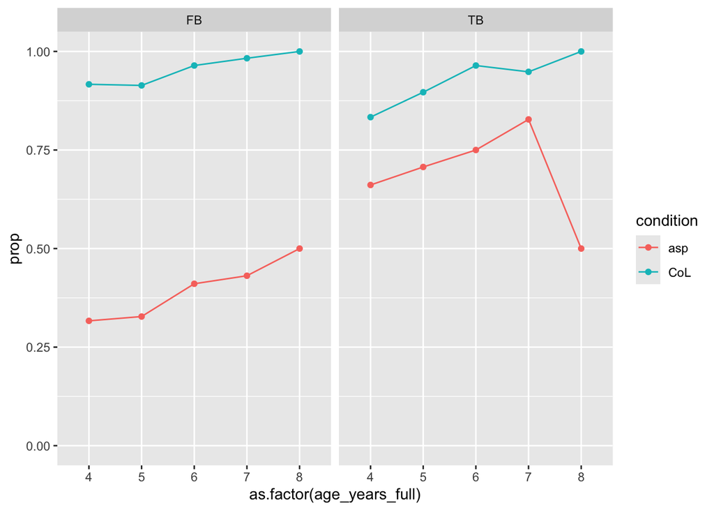

```r
plot_belief <- df_long_ex %>%
  filter(!(is.na(CQ_belief))) %>%
  group_by(belief, condition, age_years_full) %>%
  count(CQ_belief) %>%
  mutate(prop = n/sum(n))%>%
  filter(CQ_belief == "1")

ggplot(data = plot_belief, aes(x = as.factor(age_years_full), y = prop, group = condition, color = condition)) +
  geom_point(aes(group = condition)) +
  geom_line(aes(group = condition)) +
  ylim(0,1)+
  facet_wrap(~belief)
```

```r
# as a table
false.belief.s2 <- df_long_ex %>%
  filter(!is.na(CQ_belief)) %>%
  group_by(belief, condition_ref_CoL, age_years_full) %>%
  summarise(prop = mean(CQ_belief == "1")) %>%
  mutate(across(where(is.numeric), ~round(., 2))) %>%
  pivot_wider(names_from = c("belief", "condition_ref_CoL"), values_from = prop, values_fill = 0)
false.belief.s2$age_years_full[1] <- paste0(false.belief.s2$age_years_full[1], " (n = ", table(df_wide_s2$age_years_full)[1], ")")
false.belief.s2$age_years_full[2] <- paste0(false.belief.s2$age_years_full[2], " (n = ", table(df_wide_s2$age_years_full)[2], ")")
false.belief.s2$age_years_full[3] <- paste0(false.belief.s2$age_years_full[3], " (n = ", table(df_wide_s2$age_years_full)[3], ")")
false.belief.s2$age_years_full[4] <- paste0(false.belief.s2$age_years_full[4], " (n = ", table(df_wide_s2$age_years_full)[4], ")")
false.belief.s2$age_years_full[5] <- paste0(false.belief.s2$age_years_full[5], " (n = ", table(df_wide_s2$age_years_full)[5], ")")

kable(false.belief.s2, "html",
      booktabs = T,
      escape = F,
      align = c(rep("c")),
      caption = "Probability of correct false belief ascriptions per age groups, belief manipulation, and conditions",
      col.names = c("Age in years","Change of location","Dual identity", "Change of location","Dual identity")) %>%
  add_header_above(c(" " = 1, "False belief" = 2, "True belief" = 2)) %>%
  kable_styling(full_width = T)
```

Table 2.3: Probability of correct false belief ascriptions per age groups, belief manipulation, and conditions

| Age in years | False belief Change of location | False belief Dual identity | True belief Change of location | True belief Dual identity |
| --- | --- | --- | --- | --- |
| 4 (n = 32) | 0.92 | 0.32 | 0.83 | 0.66 |
| 5 (n = 29) | 0.91 | 0.33 | 0.90 | 0.71 |
| 6 (n = 28) | 0.96 | 0.41 | 0.96 | 0.75 |
| 7 (n = 29) | 0.98 | 0.43 | 0.95 | 0.83 |
| 8 (n = 1) | 1.00 | 0.50 | 1.00 | 0.50 |

# 3 Demografics table (as requested in Review Process)

```r
df_wide_s2$age_years_full[df_wide_s2$id == 146] <- 8

demo <- data.frame(age = c(4,5,6,7,8),
                   n_s1 = NA,
                   mean_s1 = NA,
                   sd_s1 = NA,
                   gender_s1 = NA,
                   n_s2 = NA,
                   mean_s2 = NA,
                   sd_s2 = NA,
                   gender_s2 = NA)

# Loop through each age in the demo table for both datasets
for (i in 1:nrow(demo)) {
  age_group <- demo$age[i]

  # Study 1
  filtered_data_s1 <- data_wide_s1 %>% filter(age_years_full == age_group)
  demo$n_s1[i] <- nrow(filtered_data_s1)
  mean_age_s1_here <- mean(filtered_data_s1$age_years, na.rm = TRUE)
  sd_age_s1_here <- sd(filtered_data_s1$age_years, na.rm = TRUE)
  gender_s1 <- if (nrow(filtered_data_s1) > 0) paste0(round(mean(filtered_data_s1$sex == "f", na.rm = TRUE)*100), "% female") else NA

  demo$mean_s1[i] <- if (!is.na(mean_age_s1_here)) convert_to_years_months(mean_age_s1_here) else NA
  demo$sd_s1[i] <- if (!is.na(sd_age_s1_here)) convert_to_years_months(sd_age_s1_here) else NA
  demo$gender_s1[i] <- gender_s1

  # Study 2
  filtered_data_s2 <- df_wide_s2 %>% filter(age_years_full == age_group)
  demo$n_s2[i] <- nrow(filtered_data_s2)
  mean_age_s2_here <- mean(filtered_data_s2$age_years, na.rm = TRUE)
  sd_age_s2_here <- sd(filtered_data_s2$age_years, na.rm = TRUE)
  gender_s2 <- if (nrow(filtered_data_s2) > 0) paste0(round(mean(filtered_data_s2$sex == "f", na.rm = TRUE)*100), "% female") else NA

  demo$mean_s2[i] <- if (!is.na(mean_age_s2_here)) convert_to_years_months(mean_age_s2_here) else NA
  demo$sd_s2[i] <- if (!is.na(sd_age_s2_here)) convert_to_years_months(sd_age_s2_here) else NA
  demo$gender_s2[i] <- gender_s2
}

# Replace all NA values with empty strings
demo[is.na(demo)] <- ""
```

```r
# Table for Study 1
demo_s1 <- demo %>%
  filter(n_s1 != "" & age != 8) %>%  # Exclude empty and age 8
  transmute(`Age ($n$)` = paste0(age, " ($n$ = ", n_s1, ")"),
            `mean age` = mean_s1,
            `SD age` = sd_s1,
            `gender` = gender_s1)

# Table for Study 2
demo_s2 <- demo %>%
  transmute(`Age ($n$)` = paste0(age, " ($n$ = ", n_s2, ")"),
            `mean age` = mean_s2,
            `SD age` = sd_s2,
            `gender` = gender_s2)
```

```r
kable(demo_s1, "html", booktabs = T, escape = F, align = c("c", "c", "c", "c"),
      caption = "Demographic distribution of age (years;months) and gender in Study 1") %>%
  kable_styling(full_width = F)
```

Table 3.1: Demographic distribution of age (years;months) and gender in Study 1

| Age ($n$) | mean age | SD age | gender |
| --- | --- | --- | --- |
| 4 ($n$ = 32) | 4;6 | 0;3 | 59% female |
| 5 ($n$ = 33) | 5;4 | 0;3 | 48% female |
| 6 ($n$ = 32) | 6;5 | 0;3 | 38% female |
| 7 ($n$ = 30) | 7;6 | 0;3 | 60% female |

```r
kable(demo_s2, "html", booktabs = T, escape = F, align = c("c", "c", "c", "c"),
      caption = "Demographic distribution of age (years;months) and gender in Study 2") %>%
  kable_styling(full_width = F)
```

Table 3.1: Demographic distribution of age (years;months) and gender in Study 2

| Age ($n$) | mean age | SD age | gender |
| --- | --- | --- | --- |
| 4 ($n$ = 32) | 4;6 | 0;3 | 47% female |
| 5 ($n$ = 29) | 5;6 | 0;3 | 52% female |
| 6 ($n$ = 28) | 6;5 | 0;3 | 54% female |
| 7 ($n$ = 29) | 7;7 | 0;2 | 52% female |
| 8 ($n$ = 1) | 8;0 |  | 100% female |

```r
#save workspace
save.image(file = paste0("workspaces/workspace_manuscript.RData"))
```